# Preparation

様々な準備を行います。

```python
import datetime, platform, os
print("Start Time: ", datetime.datetime.now())
```

```
Start Time:  2021-09-21 12:39:19.789374
```

## Google Drive に接続

```python
# 環境取得
print("This computer is [", platform.node(), platform.system(), "]")
node = platform.node()
env = ''

try:  # Google Colaboratory
    if _dh:
        env = "Colab"

        # Google Drive接続
        from google.colab import drive
        drive.mount('/content/drive')

        # 不足ライブラリのインストール
        !pip install mojimoji
        !pip install optuna
        !pip install catboost
        !pip install category_encoders
        !pip install japanize-matplotlib
        !pip install Boruta

        # パス設定
        optuna_path = 'sqlite:///drive/My Drive/Work/optuna/'
        full_path = '/content/drive/My Drive/Work/'

except:  # Local
    # パス設定
    optuna_path = 'sqlite:///optuna/'
    full_path = ''

print("The Path is [", full_path, "]")
```

```
This computer is [ DESKTOP-EJO8KHO Windows ]
The Path is [  ]
```

```python
# 乱数固定
random_seed = 42

# フォルダ作成
os.makedirs(f'{full_path}output/submission', exist_ok=True)
os.makedirs(f'{full_path}output/oof', exist_ok=True)
os.makedirs(f'{full_path}optuna', exist_ok=True)
```

## Import Libraries

```python
# 基本
import warnings
warnings.filterwarnings('ignore')
import random

# データ処理
import pandas as pd
pd.set_option('display.max_rows',200)
pd.set_option('display.max_columns',200)
import numpy as np
import math
import matplotlib
import matplotlib.pyplot as plt
import seaborn as sns
import japanize_matplotlib
sns.set(font="IPAexGothic")

# 前処理
from sklearn.preprocessing import StandardScaler, MinMaxScaler, OneHotEncoder, LabelEncoder
from sklearn.model_selection import train_test_split, KFold, GroupKFold, StratifiedKFold, TimeSeriesSplit
import mojimoji
from category_encoders.target_encoder import TargetEncoder

# 機械学習
import lightgbm as lgb
import xgboost as xgb
from catboost import CatBoost as cgb
from catboost import Pool
import tensorflow as tf
from sklearn.linear_model import ElasticNet, Lasso
from sklearn.svm import SVR
from sklearn.ensemble import RandomForestRegressor

# 評価値計算
from sklearn.metrics import mean_squared_error as mse

# その他
import optuna
from boruta import BorutaPy
```

## Helper functions

```python
def CheckDF(df):
    null_val = df.isnull().sum()
    percent = 100 * df.isnull().sum()/len(df)
    zero_val = df.shape[0] - df.apply(np.count_nonzero)
    zero_per = 100 * zero_val/len(df)
    min = df.min()
    max = df.max()
    median = df.median()
    mean = df.mean()
    std = df.std()
    type = df.dtypes
    null_table = pd.concat([null_val, percent, zero_val, zero_per, min, max, median, mean, std, type], axis=1, sort=False)
    null_check = null_table.rename(columns = {0:'欠損数', 1:'欠-%', 2:'0数', 3:'0-%', 4:'最小', 5:'最大',
                                              6:'中央', 7:'平均', 8:'標準偏差', 9:'種類'})
    return null_check
```

```python
def GetTime(df, col_nm):
    df[col_nm] = pd.to_datetime(df[col_nm])
    df['day'] = df[col_nm].dt.day
    df['month'] = df[col_nm].dt.month
    df['hour'] = df[col_nm].dt.hour
    df['dayofweek'] = df[col_nm].dt.dayofweek
    return df
```

```python
def ReduceMemUsage(df, verbose=True):
    numerics = ['int16', 'int32', 'int64', 'float16', 'float32', 'float64']
    start_mem = df.memory_usage().sum() / 1024**2
    for col in df.columns:
        col_type = df[col].dtypes
        if col_type in numerics:
            c_min = df[col].min()
            c_max = df[col].max()
            if str(col_type)[:3] == 'int':
                if c_min > np.iinfo(np.int8).min and c_max < np.iinfo(np.int8).max:
                    df[col] = df[col].astype(np.int8)
                elif c_min > np.iinfo(np.int16).min and c_max < np.iinfo(np.int16).max:
                    df[col] = df[col].astype(np.int16)
                elif c_min > np.iinfo(np.int32).min and c_max < np.iinfo(np.int32).max:
                    df[col] = df[col].astype(np.int32)
                elif c_min > np.iinfo(np.int64).min and c_max < np.iinfo(np.int64).max:
                    df[col] = df[col].astype(np.int64)
            else:
                if c_min > np.finfo(np.float16).min and c_max < np.finfo(np.float16).max:
                    df[col] = df[col].astype(np.float16)
                elif c_min > np.finfo(np.float32).min and c_max < np.finfo(np.float32).max:
                    df[col] = df[col].astype(np.float32)
                else:
                    df[col] = df[col].astype(np.float64)
    end_mem = df.memory_usage().sum() / 1024**2
    if verbose: print('Mem. usage decreased {:5.2f}Mb to {:5.2f}Mb ({:.1f}% reduction)'.format(
        start_mem, end_mem, 100 * (start_mem - end_mem) / start_mem))
    return df
```

```python
def ShowFeatureImportance(feature_importances, features, size=(10, 5)):
    feature_imp = pd.Series(feature_importances, index=features)
    matplotlib.rcParams['figure.figsize'] = size
    feature_imp.sort_values().plot(kind="barh")
    plt.title("Features Importances")
```

```python
def rmse(y_true, y_pred):
    return np.sqrt(mse(y_true, y_pred))
```

## Base Model

```python
class Base_Model(object):
    def __init__(self, train_df, test_df, objective, features, params, categoricals=[], n_splits=5, cv_method="KFold", group=None):
        self.train_df = train_df
        self.test_df = test_df
        self.features = features
        self.params = params
        self.n_splits = n_splits
        self.categoricals = categoricals
        self.target = objective
        self.cv_method = cv_method
        self.group = group
        self.cv = self.get_cv()
        self.oof_pred, self.y_pred, self.score, self.model = self.fit()

    def train_model(self, train_set, val_set):
        raise NotImplementedError

    def get_cv(self):
        if self.cv_method == "KFold":
            cv = KFold(n_splits=self.n_splits, shuffle=True, random_state=random_seed)
            return cv.split(self.train_df)
        elif self.cv_method == "StratifiedKFold":
            cv = StratifiedKFold(n_splits=self.n_splits, shuffle=True, random_state=random_seed)
            return cv.split(self.train_df, self.train_df[self.target])
        elif self.cv_method == "TimeSeriesSplit":
            cv = TimeSeriesSplit(max_train_size=None, n_splits=self.n_splits)
            return cv.split(self.train_df)
        elif self.cv_method == "GroupKFold":
            cv = GroupKFold(n_splits=self.n_splits)
            return cv.split(self.train_df, self.train_df[self.target], self.train_df[self.group])

    def get_params(self):
        raise NotImplementedError

    def convert_dataset(self, x_train, y_train, x_val, y_val):
        raise NotImplementedError

    def convert_x(self, x):
        return x

    def predict_model(self, model, x):
        return model.predict(x)

    def fit(self):
        verbosity = self.params['verbose']
        oof_pred = np.zeros((len(self.train_df), ))
        y_pred = np.zeros((len(self.test_df), ))
        print(self.train_model)
        for fold, (train_idx, val_idx) in enumerate(self.cv):
            if not verbosity==0: print('--------------------------------------------------------------------------------')
            x_train, x_val = self.train_df[self.features].iloc[train_idx], self.train_df[self.features].iloc[val_idx]
            y_train, y_val = self.train_df[self.target][train_idx], self.train_df[self.target][val_idx]
            train_set, val_set = self.convert_dataset(x_train, y_train, x_val, y_val)
            model = self.train_model(train_set, val_set)
            conv_x_val = self.convert_x(x_val)
            conv_x_train = self.convert_x(x_train)
            oof_pred[val_idx] = self.predict_model(model, conv_x_val).reshape(oof_pred[val_idx].shape)
            x_test = self.convert_x(self.test_df[self.features])
            y_pred += self.predict_model(model, x_test).reshape(y_pred.shape) / self.n_splits
            train_score = rmse(y_train, self.predict_model(model, conv_x_train))
            valid_score = rmse(y_val, oof_pred[val_idx])
            if not verbosity==0: print(f" ==>> [Fold-{fold}] {datetime.datetime.now()}")
            if not verbosity==0: print(f"        train's rmse: {train_score:.4f}  valid's rmse: {valid_score:.4f}")
        loss_score = rmse(self.train_df[self.target], oof_pred)
        if not verbosity==0: print('================================================================================')
        print("All Fold -> Our oof rmse is: {:.4f}".format(loss_score))
        return oof_pred, y_pred, loss_score, model
```

```python
class Lgb_Model(Base_Model):
    def train_model(self, train_set, val_set):
        return lgb.train(self.params, train_set, valid_sets=[train_set, val_set], verbose_eval=self.params['verbose'])

    def convert_dataset(self, x_train, y_train, x_val, y_val):
        train_set = lgb.Dataset(x_train, y_train, categorical_feature=self.categoricals)
        val_set = lgb.Dataset(x_val, y_val, categorical_feature=self.categoricals)
        return train_set, val_set
```

```python
class Cgb_Model(Base_Model):
    def train_model(self, train_set, val_set):
        params = self.params.copy()
        del params['is_probability']
        return cgb(params).fit(train_set, eval_set=val_set, verbose=self.params['verbose'])

    def convert_dataset(self, x_train, y_train, x_val, y_val):
        train_set = Pool(x_train, y_train, cat_features=self.categoricals)
        val_set = Pool(x_val, y_val, cat_features=self.categoricals)
        return train_set, val_set

    def predict_model(self, model, x):
        if self.params['is_probability']:
            return model.predict(x, prediction_type='Probability')
        else:
            return model.predict(x)
```

```python
class Xgb_Model(Base_Model):
    def train_model(self, train_set, val_set):
        return xgb.train(self.params, train_set,
                         num_boost_round=self.params['n_estimators'], evals=[(train_set, 'train'), (val_set, 'val')],
                         verbose_eval=self.params['verbose'], early_stopping_rounds=self.params['early_stopping_rounds'])

    def convert_dataset(self, x_train, y_train, x_val, y_val):
        train_set = xgb.DMatrix(x_train, y_train)
        val_set = xgb.DMatrix(x_val, y_val)
        return train_set, val_set

    def convert_x(self, x):
        return xgb.DMatrix(x)
```

```python
class Lin_Model(Base_Model):
    def __init__(self, train_df, test_df, objective, features, params, categoricals=[], n_splits=5, cv_method="KFold", group=None):
        # One-Hot Encoding
        features = features.copy()
        if len(categoricals) > 0:
            for cat in categoricals:
                enc = OneHotEncoder()
                train_cats = enc.fit_transform(train_df[[cat]])
                test_cats = enc.transform(test_df[[cat]])
                cat_cols = ['{}_{}'.format(cat, str(col)) for col in enc.categories_[0]]
                features += cat_cols
                train_cats = pd.DataFrame(train_cats.toarray(), columns=cat_cols)
                test_cats = pd.DataFrame(test_cats.toarray(), columns=cat_cols)
                train_df = pd.concat([train_df, train_cats], axis=1)
                test_df = pd.concat([test_df, test_cats], axis=1)
        # 正則化
        scalar = MinMaxScaler()
        train_df[features] = scalar.fit_transform(train_df[features])
        train_df = ReduceMemUsage(train_df, verbose=False)
        test_df[features] = scalar.transform(test_df[features])
        test_df = ReduceMemUsage(test_df, verbose=False)

        super().__init__(train_df, test_df, objective, features, params, categoricals, n_splits, cv_method, group)

    def train_model(self, train_set, val_set):
        params = self.params.copy()
        del params['verbose']
        return ElasticNet(**params).fit(train_set['X'], train_set['y'])

    def convert_dataset(self, x_train, y_train, x_val, y_val):
        train_set = {'X': x_train, 'y': y_train}
        val_set = {'X': x_val, 'y': y_val}
        return train_set, val_set
```

```python
class NnReg_Model(Base_Model):
    def __init__(self, train_df, test_df, objective, features, params, categoricals=[], n_splits=5, cv_method="KFold", group=None):
        # One-Hot Encoding
        features = features.copy()
        if len(categoricals) > 0:
            for cat in categoricals:
                enc = OneHotEncoder()
                train_cats = enc.fit_transform(train_df[[cat]])
                test_cats = enc.transform(test_df[[cat]])
                cat_cols = ['{}_{}'.format(cat, str(col)) for col in enc.categories_[0]]
                features += cat_cols
                train_cats = pd.DataFrame(train_cats.toarray(), columns=cat_cols)
                test_cats = pd.DataFrame(test_cats.toarray(), columns=cat_cols)
                train_df = pd.concat([train_df, train_cats], axis=1)
                test_df = pd.concat([test_df, test_cats], axis=1)
        # 正則化
        scalar = MinMaxScaler()
        train_df[features] = scalar.fit_transform(train_df[features])
        train_df = ReduceMemUsage(train_df, verbose=False)
        test_df[features] = scalar.transform(test_df[features])
        test_df = ReduceMemUsage(test_df, verbose=False)

        super().__init__(train_df, test_df, objective, features, params, categoricals, n_splits, cv_method, group)

    def train_model(self, train_set, val_set):
        verbosity = self.params['verbose']
        #最適化結果
        learning_rate = self.params['learning_rate']
        dropout_rate = self.params['dropout_rate']
        epochs = self.params['epochs']
        early_stopping_rounds = self.params['early_stopping_rounds']
        layer1 = self.params['layer1']
        layer2 = self.params['layer2']
        layer3 = self.params['layer3']

        ##モデル構築
        model = tf.keras.models.Sequential()
        #入力層
        model.add(tf.keras.layers.Dense(layer1, activation='relu', input_shape=(train_set['X'].shape[1],)))
        model.add(tf.keras.layers.LayerNormalization())
        model.add(tf.keras.layers.Dropout(dropout_rate))
        #中間層1
        model.add(tf.keras.layers.Dense(layer2, activation='relu'))
        model.add(tf.keras.layers.LayerNormalization())
        model.add(tf.keras.layers.Dropout(dropout_rate))
        #中間層2
        model.add(tf.keras.layers.Dense(layer3, activation='relu'))
        model.add(tf.keras.layers.LayerNormalization())
        model.add(tf.keras.layers.Dropout(dropout_rate))
        #出力層
        model.add(tf.keras.layers.Dense(1, activation='relu'))

        model.compile(
            optimizer=tf.keras.optimizers.Adam(learning_rate=learning_rate),
            loss='mse',
            metrics=[tf.keras.metrics.RootMeanSquaredError()]
        )
        if not verbosity==0: print(model.summary())
        save_best = tf.keras.callbacks.ModelCheckpoint('nn_model.w8', save_weights_only=True, save_best_only=True, verbose=verbosity)
        early_stop = tf.keras.callbacks.EarlyStopping(patience=early_stopping_rounds)
        model.fit(train_set['X'], train_set['y'], validation_data=(val_set['X'], val_set['y']),
                  epochs=epochs, verbose=verbosity, callbacks=[save_best, early_stop])
        model.load_weights('nn_model.w8')
        return model

    def convert_dataset(self, x_train, y_train, x_val, y_val):
        train_set = {'X': x_train, 'y': y_train}
        val_set = {'X': x_val, 'y': y_val}
        return train_set, val_set

class PrintDot(tf.keras.callbacks.Callback):
    def on_epoch_end(self, epoch, logs):
        if epoch % 100 == 0: print('')
        print('.', end='')
```

```python
class Svr_Model(Base_Model):
    def __init__(self, train_df, test_df, objective, features, params, categoricals=[], n_splits=5, cv_method="KFold", group=None):
        # One-Hot Encoding
        features = features.copy()
        if len(categoricals) > 0:
            for cat in categoricals:
                enc = OneHotEncoder()
                train_cats = enc.fit_transform(train_df[[cat]])
                test_cats = enc.transform(test_df[[cat]])
                cat_cols = ['{}_{}'.format(cat, str(col)) for col in enc.categories_[0]]
                features += cat_cols
                train_cats = pd.DataFrame(train_cats.toarray(), columns=cat_cols)
                test_cats = pd.DataFrame(test_cats.toarray(), columns=cat_cols)
                train_df = pd.concat([train_df, train_cats], axis=1)
                test_df = pd.concat([test_df, test_cats], axis=1)
        # 正則化
        scalar = MinMaxScaler()
        train_df[features] = scalar.fit_transform(train_df[features])
        train_df = ReduceMemUsage(train_df, verbose=False)
        test_df[features] = scalar.transform(test_df[features])
        test_df = ReduceMemUsage(test_df, verbose=False)

        super().__init__(train_df, test_df, objective, features, params, categoricals, n_splits, cv_method, group)

    def train_model(self, train_set, val_set):
        params = self.params.copy()
        del params['verbose']
        return SVR(**params).fit(train_set['X'], train_set['y'])

    def convert_dataset(self, x_train, y_train, x_val, y_val):
        train_set = {'X': x_train, 'y': y_train}
        val_set = {'X': x_val, 'y': y_val}
        return train_set, val_set
```

# Prepare Data

データを読み込んで結合します。

## Load

```python
# 学習用データ
train_base = pd.read_csv(f'{full_path}input/train.csv')
train_add = pd.read_csv(f'{full_path}input/train_add.csv')

print('Shape of train_base is ',train_base.shape)
print('Shape of train_add is ',train_add.shape)
```

```
Shape of train_base is  (1721, 11)
Shape of train_add is  (232, 11)
```

```python
# テスト用データ
test_base = pd.read_csv(f'{full_path}input/test.csv')
test_add = pd.read_csv(f'{full_path}input/2014_add.csv')
sample_submit = pd.read_csv(f'{full_path}input/sample_submit.csv', header=None, names=['id', 'y'])

print('Shape of test_base is ',test_base.shape)
print('Shape of test_add is ',test_add.shape)
print('Shape of sample_submit is ',sample_submit.shape)
```

```
Shape of test_base is  (313, 10)
Shape of test_add is  (38, 10)
Shape of sample_submit is  (313, 2)
```

```python
# 付加情報データ
stadium = pd.read_csv(f'{full_path}input/stadium.csv')
condition_base = pd.read_csv(f'{full_path}input/condition.csv')
condition_add = pd.read_csv(f'{full_path}input/condition_add.csv')

print('Shape of stadium is ',stadium.shape)
print('Shape of condition_base is ',condition_base.shape)
print('Shape of condition_add is ',condition_add.shape)
```

```
Shape of stadium is  (59, 3)
Shape of condition_base is  (2034, 31)
Shape of condition_add is  (270, 31)
```

```python
# 追加データ
player = pd.read_csv(f'{full_path}input/player.csv')
area = pd.read_csv(f'{full_path}input/area.csv')
city = pd.read_csv(f'{full_path}input/city.csv')
management = pd.read_csv(f'{full_path}input/information_2011-2013.csv')
home_stadium = pd.read_csv(f'{full_path}input/home.csv')

print('Shape of player is ',player.shape)
print('Shape of area is ',area.shape)
print('Shape of city is ',city.shape)
print('Shape of management is ',management.shape)
print('Shape of home_stadium is ',home_stadium.shape)
```

```
Shape of player is  (503, 6)
Shape of area is  (47, 4)
Shape of city is  (47, 4)
Shape of management is  (113, 60)
Shape of home_stadium is  (60, 2)
```

## Concatenate

### 追加データの結合

追加用データを結合して順序を整えます。

```python
# 学習用データ
train = pd.concat([train_base, train_add], axis=0)  # 結合
train.sort_values('id', inplace=True)  # id列を基準にソート
train.reset_index(drop=True, inplace=True)  # インデックスを再設定
```

```python
print(train.shape)
display(train.head())
```

```
(1953, 11)
```

|  | id | y | year | stage | match | gameday | time | home | away | stadium | tv |
| --- | --- | --- | --- | --- | --- | --- | --- | --- | --- | --- | --- |
| 0 | 13994 | 18250 | 2012 | Ｊ１ | 第１節第１日 | 03/10(土) | 14:04 | ベガルタ仙台 | 鹿島アントラーズ | ユアテックスタジアム仙台 | スカパー／ｅ２／スカパー光／ＮＨＫ総合 |
| 1 | 13995 | 24316 | 2012 | Ｊ１ | 第１節第１日 | 03/10(土) | 14:04 | 名古屋グランパス | 清水エスパルス | 豊田スタジアム | スカパー／ｅ２／スカパー光（Ｊ ＳＰＯＲＴＳ ４）／ＮＨＫ名古屋 |
| 2 | 13996 | 17066 | 2012 | Ｊ１ | 第１節第１日 | 03/10(土) | 14:04 | ガンバ大阪 | ヴィッセル神戸 | 万博記念競技場 | スカパー／ｅ２／スカパー光（Ｊ ＳＰＯＲＴＳ １）／ＮＨＫ大阪 |
| 3 | 13997 | 29603 | 2012 | Ｊ１ | 第１節第１日 | 03/10(土) | 14:06 | サンフレッチェ広島 | 浦和レッズ | エディオンスタジアム広島 | スカパー／ｅ２／スカパー光／ＮＨＫ広島 |
| 4 | 13998 | 25353 | 2012 | Ｊ１ | 第１節第１日 | 03/10(土) | 14:04 | コンサドーレ札幌 | ジュビロ磐田 | 札幌ドーム | スカパー／ｅ２／スカパー光（スカイ・Ａ ｓｐｏｒｔｓ＋）／ＮＨＫ札幌 |

```python
# テスト用データ
test = pd.concat([test_base, test_add], axis=0)  # 結合
test.sort_values('id', inplace=True)  # id列を基準にソート
test.reset_index(drop=True, inplace=True)  # インデックスを再設定
```

```python
print(test.shape)
display(test.head())
```

```
(351, 10)
```

|  | id | year | stage | match | gameday | time | home | away | stadium | tv |
| --- | --- | --- | --- | --- | --- | --- | --- | --- | --- | --- |
| 0 | 15822 | 2014 | Ｊ１ | 第１８節第１日 | 08/02(土) | 19:04 | ベガルタ仙台 | 大宮アルディージャ | ユアテックスタジアム仙台 | スカパー！／スカパー！プレミアムサービス |
| 1 | 15823 | 2014 | Ｊ１ | 第１８節第１日 | 08/02(土) | 18:34 | 鹿島アントラーズ | サンフレッチェ広島 | 県立カシマサッカースタジアム | スカパー！／スカパー！プレミアムサービス |
| 2 | 15824 | 2014 | Ｊ１ | 第１８節第１日 | 08/02(土) | 19:04 | 浦和レッズ | ヴィッセル神戸 | 埼玉スタジアム２００２ | スカパー！／スカパー！プレミアムサービス／ＮＨＫ ＢＳ１／テレ玉 |
| 3 | 15825 | 2014 | Ｊ１ | 第１８節第１日 | 08/02(土) | 19:03 | 柏レイソル | 川崎フロンターレ | 日立柏サッカー場 | スカパー！／スカパー！プレミアムサービス |
| 4 | 15826 | 2014 | Ｊ１ | 第１８節第１日 | 08/02(土) | 18:34 | ＦＣ東京 | 清水エスパルス | 味の素スタジアム | スカパー！／スカパー！プレミアムサービス／ＴＯＫＹＯ ＭＸ |

```python
# 付加情報データ
condition = pd.concat([condition_base, condition_add], axis=0)  # 結合
condition.sort_values('id', inplace=True)  # id列を基準にソート
condition.reset_index(drop=True, inplace=True)  # インデックスを再設定
```

```python
print(condition.shape)
display(condition.head())
```

```
(2304, 31)
```

|  | id | home_score | away_score | weather | temperature | humidity | referee | home_team | home_01 | home_02 | home_03 | home_04 | home_05 | home_06 | home_07 | home_08 | home_09 | home_10 | home_11 | away_team | away_01 | away_02 | away_03 | away_04 | away_05 | away_06 | away_07 | away_08 | away_09 | … |
| --- | --- | --- | --- | --- | --- | --- | --- | --- | --- | --- | --- | --- | --- | --- | --- | --- | --- | --- | --- | --- | --- | --- | --- | --- | --- | --- | --- | --- | --- | --- |
| 0 | 13994 | 1 | 0 | 雨 | 3.8 | 66% | 木村 博之 | ベガルタ仙台 | 林 卓人 | 菅井 直樹 | 鎌田 次郎 | 上本 大海 | 田村 直也 | 富田 晋伍 | 角田 誠 | 太田 吉彰 | 関口 訓充 | ウイルソン | 赤嶺 真吾 | 鹿島アントラーズ | 曽ヶ端 準 | 新井場 徹 | 岩政 大樹 | 中田 浩二 | アレックス | 青木 剛 | 増田 誓志 | 小笠原 満男 | 本山 雅志 | … |
| 1 | 13995 | 1 | 0 | 屋内 | 12.4 | 43% | 西村 雄一 | 名古屋グランパス | 楢﨑 正剛 | 田中 隼磨 | 田中 マルクス闘莉王 | 増川 隆洋 | 阿部 翔平 | 中村 直志 | ダニルソン | 藤本 淳吾 | 金崎 夢生 | ケネディ | 玉田 圭司 | 清水エスパルス | 林 彰洋 | 吉田 豊 | 岩下 敬輔 | カルフィン ヨン ア ピン | 李 記帝 | 村松 大輔 | 河井 陽介 | 枝村 匠馬 | 高木 俊幸 | … |
| 2 | 13996 | 2 | 3 | 晴一時雨 | 11.3 | 41% | 高山 啓義 | ガンバ大阪 | 藤ヶ谷 陽介 | 加地 亮 | 中澤 聡太 | 今野 泰幸 | 藤春 廣輝 | 明神 智和 | 遠藤 保仁 | 佐々木 勇人 | 二川 孝広 | ラフィーニャ | パウリーニョ | ヴィッセル神戸 | 徳重 健太 | 近藤 岳登 | 北本 久仁衛 | 伊野波 雅彦 | 相馬 崇人 | 三原 雅俊 | 田中 英雄 | 野沢 拓也 | 橋本 英郎 | … |
| 3 | 13997 | 1 | 0 | 曇一時雨のち晴 | 11.4 | 52% | 松尾 一 | サンフレッチェ広島 | 西川 周作 | 森脇 良太 | 千葉 和彦 | 水本 裕貴 | ミキッチ | 青山 敏弘 | 森﨑 和幸 | 山岸 智 | 石原 直樹 | 髙萩 洋次郎 | 佐藤 寿人 | 浦和レッズ | 加藤 順大 | 濱田 水輝 | 阿部 勇樹 | 槙野 智章 | 平川 忠亮 | 鈴木 啓太 | 山田 直輝 | 梅崎 司 | 柏木 陽介 | … |
| 4 | 13998 | 0 | 0 | 屋内 | 22.5 | 32% | 廣瀬 格 | コンサドーレ札幌 | 李 昊乗 | 高木 純平 | ジェイド ノース | 奈良 竜樹 | 岩沼 俊介 | 河合 竜二 | 山本 真希 | 近藤 祐介 | 内村 圭宏 | 岡本 賢明 | 前田 俊介 | ジュビロ磐田 | 川口 能活 | 駒野 友一 | チョ ビョングク | 藤田 義明 | 山本 脩斗 | 小林 裕紀 | 山本 康裕 | 山田 大記 | 松浦 拓弥 | … |

### 学習用・テスト用データの結合

この後処理をまとめて行うため、学習用データとテスト用データを縦方向に結合します。 学習時には、id列を基に分割して利用します。

```python
df = pd.concat([train, test], axis=0)  # 結合
df.reset_index(drop=True, inplace=True)  # インデックスを再設定
```

```python
print(df.shape)
display(pd.concat([df.head(3), df.tail(3)], axis=0))
```

```
(2304, 11)
```

|  | id | y | year | stage | match | gameday | time | home | away | stadium | tv |
| --- | --- | --- | --- | --- | --- | --- | --- | --- | --- | --- | --- |
| 0 | 13994 | 18250.0 | 2012 | Ｊ１ | 第１節第１日 | 03/10(土) | 14:04 | ベガルタ仙台 | 鹿島アントラーズ | ユアテックスタジアム仙台 | スカパー／ｅ２／スカパー光／ＮＨＫ総合 |
| 1 | 13995 | 24316.0 | 2012 | Ｊ１ | 第１節第１日 | 03/10(土) | 14:04 | 名古屋グランパス | 清水エスパルス | 豊田スタジアム | スカパー／ｅ２／スカパー光（Ｊ ＳＰＯＲＴＳ ４）／ＮＨＫ名古屋 |
| 2 | 13996 | 17066.0 | 2012 | Ｊ１ | 第１節第１日 | 03/10(土) | 14:04 | ガンバ大阪 | ヴィッセル神戸 | 万博記念競技場 | スカパー／ｅ２／スカパー光（Ｊ ＳＰＯＲＴＳ １）／ＮＨＫ大阪 |
| 2301 | 16434 | NaN | 2014 | Ｊ２ | 第４２節第１日 | 11/23(日・祝) | 14:03 | カマタマーレ讃岐 | ジェフユナイテッド千葉 | 香川県立丸亀競技場 | スカパー！／スカパー！プレミアムサービス |
| 2302 | 16435 | NaN | 2014 | Ｊ２ | 第４２節第１日 | 11/23(日・祝) | 14:04 | アビスパ福岡 | ロアッソ熊本 | レベルファイブスタジアム | スカパー！／スカパー！プレミアムサービス |
| 2303 | 16436 | NaN | 2014 | Ｊ２ | 第４２節第１日 | 11/23(日・祝) | 14:03 | 大分トリニータ | 湘南ベルマーレ | 大分銀行ドーム | スカパー！／スカパー！プレミアムサービス／ＮＨＫ大分 |

# Visualization

用意したデータを可視化します。

```python
df_v = df.merge(condition)
df_v_train = df_v[~df_v['y'].isnull()]
df_v_test = df_v[df_v['y'].isnull()]
```

### 基本統計量

```python
CheckDF(df_v)
```

|  | 欠損数 | 欠-% | 0数 | 0-% | 最小 | 最大 | 中央 | 平均 | 標準偏差 | 種類 |
| --- | --- | --- | --- | --- | --- | --- | --- | --- | --- | --- |
| id | 0 | 0.000000 | 0 | 0.000000 | 13994 | 16436 | 15219.5 | 15216.484375 | 719.006461 | int64 |
| y | 351 | 15.234375 | 1 | 0.043403 | 0 | 62632 | 8594.0 | 10629.558116 | 8102.315189 | float64 |
| year | 0 | 0.000000 | 0 | 0.000000 | 2012 | 2014 | 2013.0 | 2013.000000 | 0.816674 | int64 |
| stage | 0 | 0.000000 | 0 | 0.000000 | Ｊ１ | Ｊ２ | NaN | NaN | NaN | object |
| match | 0 | 0.000000 | 0 | 0.000000 | 第１節第１日 | 第９節第２日 | NaN | NaN | NaN | object |
| gameday | 0 | 0.000000 | 0 | 0.000000 | 03/01(土) | 12/08(月) | NaN | NaN | NaN | object |
| time | 0 | 0.000000 | 0 | 0.000000 | 12:33 | 20:04 | NaN | NaN | NaN | object |
| home | 0 | 0.000000 | 0 | 0.000000 | アビスパ福岡 | Ｖ・ファーレン長崎 | NaN | NaN | NaN | object |
| away | 0 | 0.000000 | 0 | 0.000000 | アビスパ福岡 | Ｖ・ファーレン長崎 | NaN | NaN | NaN | object |
| stadium | 0 | 0.000000 | 0 | 0.000000 | うまかな・よかなスタジアム | Ｓｈｏｎａｎ ＢＭＷスタジアム平塚 | NaN | NaN | NaN | object |
| tv | 0 | 0.000000 | 0 | 0.000000 | スカパー！ | スカパー／ｅ２／スカパー光／ＴＯＫＹＯ ＭＸ（録） | NaN | NaN | NaN | object |
| home_score | 0 | 0.000000 | 598 | 25.954861 | 0 | 7 | 1.0 | 1.370226 | 1.194356 | int64 |
| away_score | 0 | 0.000000 | 698 | 30.295139 | 0 | 8 | 1.0 | 1.197917 | 1.121717 | int64 |
| weather | 0 | 0.000000 | 0 | 0.000000 | 屋内 | 雪のち雨 | NaN | NaN | NaN | object |
| temperature | 0 | 0.000000 | 0 | 0.000000 | 1.3 | 34.2 | 21.7 | 20.642969 | 6.255947 | float64 |
| humidity | 0 | 0.000000 | 0 | 0.000000 | 12% | 99% | NaN | NaN | NaN | object |
| referee | 0 | 0.000000 | 0 | 0.000000 | アントニオ アリアス | 高山 啓義 | NaN | NaN | NaN | object |
| home_team | 0 | 0.000000 | 0 | 0.000000 | アビスパ福岡 | Ｖ・ファーレン長崎 | NaN | NaN | NaN | object |
| home_01 | 0 | 0.000000 | 0 | 0.000000 | アレックス サンターナ | 黒河 貴矢 | NaN | NaN | NaN | object |
| home_02 | 0 | 0.000000 | 0 | 0.000000 | アライール | 髙杉 亮太 | NaN | NaN | NaN | object |
| home_03 | 0 | 0.000000 | 0 | 0.000000 | アライール | 黒木 聖仁 | NaN | NaN | NaN | object |
| home_04 | 0 | 0.000000 | 0 | 0.000000 | アライール | 黒木 恭平 | NaN | NaN | NaN | object |
| home_05 | 0 | 0.000000 | 0 | 0.000000 | アレックス | 黒木 聖仁 | NaN | NaN | NaN | object |
| home_06 | 0 | 0.000000 | 0 | 0.000000 | アレックス | 齊藤 和樹 | NaN | NaN | NaN | object |
| home_07 | 0 | 0.000000 | 0 | 0.000000 | アレックス | 黒木 聖仁 | NaN | NaN | NaN | object |
| home_08 | 0 | 0.000000 | 0 | 0.000000 | アラン ミネイロ | 黒木 聖仁 | NaN | NaN | NaN | object |
| home_09 | 0 | 0.000000 | 0 | 0.000000 | アラン ピニェイロ | 齋藤 学 | NaN | NaN | NaN | object |
| home_10 | 0 | 0.000000 | 0 | 0.000000 | アドリアーノ | 齋藤 学 | NaN | NaN | NaN | object |
| home_11 | 0 | 0.000000 | 0 | 0.000000 | アドリアーノ | 齋藤 学 | NaN | NaN | NaN | object |
| away_team | 0 | 0.000000 | 0 | 0.000000 | アビスパ福岡 | Ｖ・ファーレン長崎 | NaN | NaN | NaN | object |
| away_01 | 0 | 0.000000 | 0 | 0.000000 | アレックス サンターナ | 黒河 貴矢 | NaN | NaN | NaN | object |
| away_02 | 0 | 0.000000 | 0 | 0.000000 | アライール | 黒木 晃平 | NaN | NaN | NaN | object |
| away_03 | 0 | 0.000000 | 0 | 0.000000 | アライール | 黄 誠秀 | NaN | NaN | NaN | object |
| away_04 | 0 | 0.000000 | 0 | 0.000000 | アライール | 黒木 恭平 | NaN | NaN | NaN | object |
| away_05 | 0 | 0.000000 | 0 | 0.000000 | アレックス | 黒木 聖仁 | NaN | NaN | NaN | object |
| away_06 | 0 | 0.000000 | 0 | 0.000000 | アン ヨンギュ | 齊藤 和樹 | NaN | NaN | NaN | object |
| away_07 | 0 | 0.000000 | 0 | 0.000000 | アレックス | 黒木 聖仁 | NaN | NaN | NaN | object |
| away_08 | 0 | 0.000000 | 0 | 0.000000 | アラン ミネイロ | 黒津 勝 | NaN | NaN | NaN | object |
| away_09 | 0 | 0.000000 | 0 | 0.000000 | アラン ピニェイロ | 齋藤 学 | NaN | NaN | NaN | object |
| away_10 | 0 | 0.000000 | 0 | 0.000000 | アドリアーノ | 齋藤 学 | NaN | NaN | NaN | object |
| away_11 | 0 | 0.000000 | 0 | 0.000000 | アブダ | 齋藤 学 | NaN | NaN | NaN | object |

```python
CheckDF(management)
```

|  | 欠損数 | 欠-% | 0数 | 0-% | 最小 | 最大 | 中央 | 平均 | 標準偏差 | 種類 |
| --- | --- | --- | --- | --- | --- | --- | --- | --- | --- | --- |
| クラブ | 0 | 0.000000 | 0 | 0.000000 | C大阪 | 鹿島 | NaN | NaN | NaN | object |
| 年 | 0 | 0.000000 | 0 | 0.000000 | 2011 | 2013 | 2012.0000 | 2012.044248 | 0.827964 | int64 |
| 所属 | 0 | 0.000000 | 0 | 0.000000 | J1 | JFL | NaN | NaN | NaN | object |
| id | 0 | 0.000000 | 0 | 0.000000 | albirex | zweigen | NaN | NaN | NaN | object |
| 呼称 | 0 | 0.000000 | 0 | 0.000000 | FC東京 | 鹿島アントラーズ | NaN | NaN | NaN | object |
| ライセンス | 36 | 31.858407 | 0 | 0.000000 | NaN | NaN | NaN | NaN | NaN | object |
| 順位 | 0 | 0.000000 | 0 | 0.000000 | 1 | 22 | 9.0000 | 9.283186 | 5.334304 | int64 |
| 勝ち点 | 0 | 0.000000 | 0 | 0.000000 | 14 | 87 | 55.0000 | 53.362832 | 13.669610 | int64 |
| PPG | 0 | 0.000000 | 0 | 0.000000 | 0.4118 | 2.1176 | 1.4706 | 1.436274 | 0.336911 | float64 |
| 昇降格 | 92 | 81.415929 | 0 | 0.000000 | NaN | NaN | NaN | NaN | NaN | object |
| 営業収入 | 0 | 0.000000 | 0 | 0.000000 | 66 | 5786 | 1470.0000 | 1981.176991 | 1353.509692 | int64 |
| 営業費用 | 0 | 0.000000 | 0 | 0.000000 | 115 | 5633 | 1463.0000 | 1977.345133 | 1345.103831 | int64 |
| 営業利益 | 0 | 0.000000 | 2 | 1.769912 | -512 | 518 | 6.0000 | 3.849558 | 143.569061 | int64 |
| 営業外収益 | 0 | 0.000000 | 22 | 19.469027 | 0 | 180 | 11.0000 | 19.159292 | 31.505262 | int64 |
| 営業外費用 | 0 | 0.000000 | 15 | 13.274336 | -36 | 166 | 4.0000 | 7.557522 | 18.971754 | int64 |
| 経常利益 | 0 | 0.000000 | 1 | 0.884956 | -518 | 365 | 8.0000 | 15.433628 | 137.769015 | int64 |
| 特別利益 | 0 | 0.000000 | 93 | 82.300885 | 0 | 1000 | 0.0000 | 15.920354 | 98.288582 | int64 |
| 特別損失 | 0 | 0.000000 | 74 | 65.486726 | 0 | 252 | 0.0000 | 10.433628 | 35.118645 | int64 |
| 税引前当期利益 | 0 | 0.000000 | 0 | 0.000000 | -628 | 1000 | 8.0000 | 19.982301 | 175.619362 | int64 |
| 法人税および住民税等 | 0 | 0.000000 | 34 | 30.088496 | -29 | 134 | 1.0000 | 12.336283 | 25.253928 | int64 |
| 当期純利益 | 0 | 0.000000 | 4 | 3.539823 | -629 | 1000 | 6.0000 | 7.637168 | 167.386639 | int64 |
| 関連する法人の営業収入 | 113 | 100.000000 | 0 | 0.000000 | NaN | NaN | NaN | NaN | NaN | float64 |
| 総資産 | 0 | 0.000000 | 0 | 0.000000 | 27 | 2456 | 623.0000 | 739.486726 | 590.293437 | int64 |
| 流動資産 | 0 | 0.000000 | 0 | 0.000000 | 9 | 1839 | 354.0000 | 426.672566 | 355.605631 | int64 |
| 固定資産等 | 0 | 0.000000 | 0 | 0.000000 | 4 | 2242 | 147.0000 | 312.778761 | 426.071249 | int64 |
| 総負債 | 0 | 0.000000 | 0 | 0.000000 | 18 | 2456 | 509.0000 | 559.415929 | 492.367961 | int64 |
| 流動負債 | 0 | 0.000000 | 0 | 0.000000 | 18 | 2301 | 334.0000 | 407.548673 | 374.879433 | int64 |
| 固定負債 | 0 | 0.000000 | 13 | 11.504425 | 0 | 1991 | 63.0000 | 151.831858 | 304.629896 | int64 |
| 純資産 | 0 | 0.000000 | 1 | 0.884956 | -1677 | 1590 | 92.0000 | 180.088496 | 530.908614 | int64 |
| 資本金 | 0 | 0.000000 | 3 | 2.654867 | 0 | 3605 | 276.0000 | 446.353982 | 635.532523 | int64 |
| 資本剰余金等 | 0 | 0.000000 | 59 | 52.212389 | -1 | 932 | 0.0000 | 103.893805 | 191.677434 | int64 |
| 利益剰余金 | 0 | 0.000000 | 2 | 1.769912 | -3580 | 460 | -156.0000 | -370.469027 | 703.715104 | int64 |
| 広告料収入 | 0 | 0.000000 | 0 | 0.000000 | 23 | 2457 | 682.0000 | 915.380531 | 670.827505 | int64 |
| 入場料収入 | 0 | 0.000000 | 0 | 0.000000 | 5 | 2132 | 329.0000 | 399.513274 | 366.351732 | int64 |
| Jリーグ配分金 | 0 | 0.000000 | 4 | 3.539823 | 0 | 268 | 110.0000 | 152.787611 | 73.790540 | int64 |
| アカデミー関連収入 | 0 | 0.000000 | 8 | 7.079646 | 0 | 458 | 57.0000 | 105.716814 | 109.151473 | int64 |
| 物販収入 | 113 | 100.000000 | 0 | 0.000000 | NaN | NaN | NaN | NaN | NaN | float64 |
| その他収入 | 0 | 0.000000 | 0 | 0.000000 | 15 | 1353 | 261.0000 | 407.823009 | 325.535170 | int64 |
| チーム人件費 | 0 | 0.000000 | 0 | 0.000000 | 35 | 2348 | 671.0000 | 878.283186 | 629.771734 | int64 |
| 試合関連経費 | 0 | 0.000000 | 0 | 0.000000 | 3 | 615 | 141.0000 | 169.796460 | 127.673213 | int64 |
| トップチーム運営経費 | 0 | 0.000000 | 0 | 0.000000 | 14 | 652 | 172.0000 | 201.389381 | 125.857660 | int64 |
| アカデミー運営経費 | 0 | 0.000000 | 10 | 8.849558 | 0 | 315 | 59.0000 | 73.389381 | 71.039782 | int64 |
| 女子チーム運営経費 | 0 | 0.000000 | 93 | 82.300885 | 0 | 69 | 0.0000 | 5.646018 | 15.715052 | int64 |
| 物販関連費 | 113 | 100.000000 | 0 | 0.000000 | NaN | NaN | NaN | NaN | NaN | float64 |
| 事業費 | 113 | 100.000000 | 0 | 0.000000 | NaN | NaN | NaN | NaN | NaN | float64 |
| 販売費および一般管理費 | 0 | 0.000000 | 0 | 0.000000 | 58 | 2522 | 501.0000 | 648.761062 | 483.656705 | int64 |
| 総入場者数 | 0 | 0.000000 | 0 | 0.000000 | 30057 | 745579 | 200525.0000 | 215270.371681 | 132518.864683 | int64 |
| ホーム総試合数 | 0 | 0.000000 | 0 | 0.000000 | 17 | 25 | 20.0000 | 19.911504 | 1.677357 | int64 |
| リーグ平均入場者数 | 0 | 0.000000 | 0 | 0.000000 | 1768 | 37100 | 10407.0000 | 11341.274336 | 7276.322519 | int64 |
| 客単価 | 0 | 0.000000 | 0 | 0.000000 | 142 | 3327 | 1603.0000 | 1597.734513 | 605.737317 | int64 |
| リーグ戦入場者数 | 0 | 0.000000 | 0 | 0.000000 | 30057 | 630701 | 199162.0000 | 203196.584071 | 119369.535703 | int64 |
| リーグ戦ホーム試合数 | 0 | 0.000000 | 0 | 0.000000 | 17 | 21 | 17.0000 | 18.557522 | 1.807416 | int64 |
| リーグカップ入場者数 | 0 | 0.000000 | 77 | 68.141593 | 0 | 53942 | 0.0000 | 8113.008850 | 14030.351542 | int64 |
| リーグカップホーム試合数 | 0 | 0.000000 | 77 | 68.141593 | 0 | 5 | 0.0000 | 0.955752 | 1.525904 | int64 |
| PO入場者数 | 0 | 0.000000 | 109 | 96.460177 | 0 | 12387 | 0.0000 | 380.902655 | 2007.935138 | int64 |
| POホーム試合数 | 0 | 0.000000 | 109 | 96.460177 | 0 | 1 | 0.0000 | 0.035398 | 0.185607 | int64 |
| ACL入場者数 | 0 | 0.000000 | 101 | 89.380531 | 0 | 64938 | 0.0000 | 3579.876106 | 11517.773643 | int64 |
| ACLホーム試合数 | 0 | 0.000000 | 101 | 89.380531 | 0 | 6 | 0.0000 | 0.362832 | 1.094319 | int64 |
| セカンドチーム入場者数 | 113 | 100.000000 | 0 | 0.000000 | NaN | NaN | NaN | NaN | NaN | float64 |
| セカンドチームホーム試合数 | 113 | 100.000000 | 0 | 0.000000 | NaN | NaN | NaN | NaN | NaN | float64 |

## グラフ化

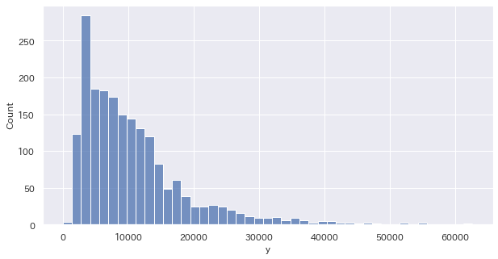

```python
plt.figure(figsize=(10, 5))
sns.histplot(x="y", data=df_v_train)
plt.show()
```

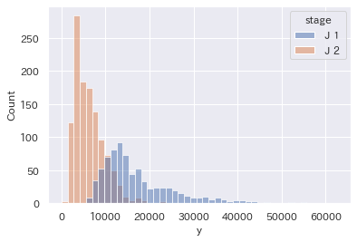

```python
sns.histplot(x="y", data=df_v_train, hue="stage")
plt.show()  # J1/J2で分布が異なる
```

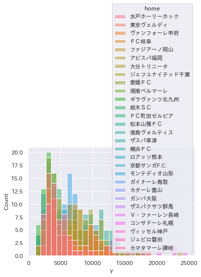

```python
df_v_train_J1 = df_v_train[df_v_train['stage']=='Ｊ２']
sns.histplot(x="y", data=df_v_train_J1, hue="home")
plt.show()  # J1/J2で分布が異なる
```

# Preprocessing

前処理を行います。

## Cleansing / Feature Engineering

### 学習用・テスト用データに対する処理

#### 不要列の削除準備

```python
# 後から削除する列リストを設定
drop_cols = []
```

```python
# year列（開催年度）は、学習用データとテスト用データでほぼ排他なので不要
drop_cols.append('year')
```

#### match列（開催節）の処理

「第〇節第●日」の「〇」と「●」情報を抽出します。

```python
df['match_section'] = df['match'].str.split('第', expand=True)[1].str.split('節', expand=True)[0]  # 節情報だけ抽出
df['match_section'] = df['match_section'].apply(lambda x:mojimoji.zen_to_han(x))  # 全角文字を半角文字に変換
df['match_section'] = df['match_section'].astype('int16')  # 数値に変換

df['match_day'] = df['match'].str.split('第', expand=True)[2].str.split('日', expand=True)[0]  # 節情報だけ抽出
df['match_day'] = df['match_day'].apply(lambda x:mojimoji.zen_to_han(x))  # 全角文字を半角文字に変換
df['match_day'] = df['match_day'].astype('int16')  # 数値に変換
```

```python
# 寄与度が大きい開催節の別特徴量を生成
stages = ['Ｊ１', 'Ｊ２']

# シーズンをn+1分割
bins = 5
_list = []
for i in stages:
    df_part = df[df['stage']==i]
    bin_width = math.floor(df_part['match_section'].max()/bins)  # 1つのビンに含める開催節の数を設定
    df_part['match_section_bins'] = df_part['match_section']//bin_width  # 数で割った商をビンのグループに設定
    _list.append(df_part)
df = pd.concat(_list).sort_index()

# 対称データ(テストデータが後半だけのため)
section_median = []
_list = []
for i in stages:
    df_part = df[df['stage']==i]
    section_median = math.floor(df_part['match_section'].median())  # 開催節の中央値を設定
    df_part['match_section_symmetry'] = abs(df_part['match_section'] - section_median)  # 数で割った商をビンのグループに設定
    _list.append(df_part)
df = pd.concat(_list).sort_index()
```

```python
# 後から削除する列リストに追加
drop_cols.append('match')
```

#### gameday列（試合日）の処理

月・日・曜日情報を抽出します。

```python
def func_day(x):
    holidays = ['祝', '休']
    saturday = ['土']
    sunday = ['日']
    for h in holidays:
        if h in x:
            res=1
            return res
    if x in saturday:
        res=2
    elif x in sunday:
        res=3
    else:  # 平日
        res=0
    return res
```

```python
df['gameday_month'] = df['gameday'].str.split('\/', expand=True)[0].astype('int16')  # 月情報だけ抽出してintに変換
df['gameday_date'] = df['gameday'].str.split('\/', expand=True)[1].str.split('\(', expand=True)[0].astype('int16')  # 日情報だけ抽出してintに変換

df['gameday_day'] = df['gameday'].str.split('\(', expand=True)[1].str.split('\)', expand=True)[0]  # 曜日情報だけ抽出
df['gameday_day'] = df['gameday_day'].apply(lambda x:func_day(x))  # 曜日情報を数値に変換
```

```python
# 後から削除する列リストに追加
drop_cols.append('gameday')
```

#### time列（キックオフ時間）の処理

「〇時●分」の「〇」情報だけ抽出します。

```python
df['time'] = df['time'].str.split('\:', expand=True)[0].astype('int16')  # 時間情報だけ抽出
```

#### tv列（TV放送）の処理

TV放送の列に分割して数値化します。

```python
df['tv'] = df['tv'].str.split('／')  # TV放送をリスト化
```

```python
# TV放送の有無を1/0で表すOne-Hotベクトルのテーブルに変換
tv_list = []
_list = []
for tv in df['tv']:  # データフレームの行繰り返し
    _dict = {}
    for t in tv:  # TV放送のリスト繰り返し
        # 名寄せ処理
        t = t.split('（')[0]  # "（）"の手前で切り出し
        t = t.split('※')[0]  # "※"の手前で切り出し
        t = t.replace('光', '')  # "！"は削除

        # 辞書型で保持
        _dict[t] = 1
        tv_list.append(t)
    # 辞書型の要素をリスト型で保持
    _list.append(_dict)

# リストからTV放送データフレームを生成
tv_table = pd.DataFrame(_list).fillna(0)
```

```python
# TV放送データフレームを結合 -> 列数が多いわりに情報が少なく精度が下がるため除外
# df = pd.concat([df, tv_table], axis=1)
```

```python
# tv列はTV放送数に変換
df['tv'] = df['tv'].apply(lambda x: len(x))
```

#### home, away列（ホーム/アウェイチーム名）の処理

チーム名の名寄せと、半角から全角への変換を行います。

```python
# 変更されたチーム名を修正
df.replace('ザスパ草津', 'ザスパクサツ群馬', inplace=True)

# 半角英数を全角に変換
df['home'] = df['home'].apply(lambda x: mojimoji.han_to_zen(x))
df['away'] = df['away'].apply(lambda x: mojimoji.han_to_zen(x))
```

#### 他の文字型の列

ラベルエンコーディングで文字型を数値型に変換します。

```python
le = LabelEncoder()
```

```python
# 開催大会 -> J1/J2で別モデルを作る場合には不要
df['stage'] = le.fit_transform(df['stage'])
print("LabelEncoder classees: ", list(le.classes_))

# ホームチーム、アウェイチーム -> マージするためマージ後に実施
# df['home'] = le.fit_transform(df['home'])
# df['away'] = le.transform(df['away'])
# print("LabelEncoder classees: ", list(le.classes_))
```

```
LabelEncoder classees:  ['Ｊ１', 'Ｊ２']
```

### 付加情報データに対する処理

#### 不要列の削除準備

```python
# 試合詳細データの*_score列（スコア）は、試合開始時点で知りえない情報のため削除（前試合のスコアや累積スコアを取得して計算する方法もあるが今回は省略）
drop_cols.append('home_score')
drop_cols.append('away_score')
```

```python
# 試合詳細データのhome_team, away_team列（ホームチーム、アウェイチーム）は、home, away列と重複するため不要
drop_cols.append('home_team')
drop_cols.append('away_team')
```

#### weather列（天候）の処理

様々な天候が含まれているため、「晴」「曇」「雨」「屋内」に分類して数値型に変換します。

```python
def func_weather(x):
    if x=='晴':
        res=0
    elif x=='曇':
        res=1
    elif x=='雨':
        res=2
    elif x=='屋内':
        res=3
    elif '雨' in x:  # "雨"が含まれていたら雨に分類
        res=2
    else:  # それ以外は中間の"曇"に分類
        res=1
    return res
```

```python
condition['weather'] = condition['weather'].apply(lambda x:func_weather(x))  # 関数に従い数値に変換
```

#### humidity列（湿度）の処理

「〇%」の「〇」情報だけ抽出します。

```python
condition['humidity'] = condition['humidity'].str.split('\%', expand=True)[0].astype('int16')  # 湿度数値情報だけ抽出
```

#### address列（所在地）の処理

マージキーとなる都道府県を抽出します。

```python
stadium['address'] = stadium['address'].str.split('県', expand=True)[0]
stadium['address'] = stadium['address'].str.split('都', expand=True)[0]
stadium['address'] = stadium['address'].str.split('府', expand=True)[0]
stadium['address'] = stadium['address'].str.split('道', expand=True)[0]
```

#### 他の文字型の列

ラベルエンコーディングで数値に変換します。

```python
# 主審
condition['referee'] = le.fit_transform(condition['referee'])
print("LabelEncoder classees: ", list(le.classes_))
```

```
LabelEncoder classees:  ['アントニオ\u3000アリアス', 'クート\u3000デービッド', 'ケビン\u3000フレンド', 'シモン\u3000マルチニアク', 'ジェームズ\u3000アドコック', 'スティーブン\u3000マーティン', 'ダーレン\u3000デッドマン', 'ティアニー\u3000ポール', 'パベル\u3000ラチコフスキ', '三上\u3000正一郎', '上村\u3000篤史', '上田\u3000益也', '中村\u3000太', '井上\u3000知大', '今村\u3000亮一', '今村\u3000義朗', '佐藤\u30…
```

### 追加データに対する処理

#### 不要列の削除準備

```python
# 市名情報は使うタイミングがないため削除
drop_cols.append('city')
```

```python
# 欠損値が含まれる列名を取得
isnull_cols = list(df.T[df.isnull().any()].index)
# 目的変数yを除外
isnull_cols.remove('y')
# 中央値で欠損値補完
df[isnull_cols] = df[isnull_cols].fillna(df.median())
```

```python
# Managementは複数結合するためこの時点で不要列を削除
drop_cols_management = []

# 標準偏差が0の数値列は削除（変化がないため入れるべきでない）
dsc = management.describe().T
drop_cols_management.extend(dsc[dsc['std'].isnull()].index.to_list())

# 経営情報で分析に使わない列を削除
drop_cols_management.extend(['クラブ', '所属', 'id', 'ライセンス'])
management.drop(drop_cols_management, axis=1, inplace=True)
```

#### 県名列の処理

後からマージするために、末尾の「都」「道」「府」「県」の文字を取り除きます。

```python
area['prefecture'] = area['prefecture'].str.translate(str.maketrans({'都':'', '道':'', '府':'', '県':'' }))
city['prefecture'] = city['prefecture'].str.translate(str.maketrans({'都':'', '道':'', '府':'', '県':'' }))
```

#### 経営情報の年列の処理

同じ年で結合すると未来の情報が含まれてしまうため、結合できるように年を修正する。

```python
management['年'] = management['年'] + 1
```

#### クラブ名の処理

チーム名の名寄せと、半角から全角への変換を行います。

```python
# 変更されたチーム名を修正
management.replace('ザスパ草津', 'ザスパクサツ群馬', inplace=True)

# 半角英数を全角に変換
management['呼称'] = management['呼称'].apply(lambda x: mojimoji.han_to_zen(x))
```

#### 昇降格列の処理

```python
# 欠損値処理
management['昇降格'].fillna('昇降格なし', inplace=True)

# ラベルエンコーディング
management['昇降格'] = le.fit_transform(management['昇降格'])
print("LabelEncoder classees: ", list(le.classes_))
```

```
LabelEncoder classees:  ['昇格', '昇降格なし', '降格']
```

### 特徴量生成

#### 数値データの組み合わせ

```python
# 不快指数(temperature-humidity index)を計算して追加
T = condition['temperature']
H = condition['humidity']
condition['THI'] = 0.81*T + 0.01*H*(0.99*T-14.3) + 46.3
```

#### カテゴリデータの組み合わせ

```python
# スタジアムとチームの組み合わせを新たな特徴量として追加
df['stadium_home'] = (df['stadium'] + df['home'].astype('str'))
df['stadium_away'] = (df['stadium'] + df['away'].astype('str'))

df['stadium_home'] = le.fit_transform(df['stadium_home'])
#print("LabelEncoder classees: ", list(le.classes_))

df['stadium_away'] = le.fit_transform(df['stadium_away'])
#print("LabelEncoder classees: ", list(le.classes_))
```

```python
# 寄与度が大きい開催節とJ1/J2の組み合わせを新たな特徴量として追加
df['stage_match'] = (df['stage'].astype('str') + '_' + df['match_section_symmetry'].astype('str'))

df['stage_match'] = le.fit_transform(df['stage_match'])
print("LabelEncoder classees: ", list(le.classes_))
```

```
LabelEncoder classees:  ['0_0', '0_1', '0_10', '0_11', '0_12', '0_13', '0_14', '0_15', '0_16', '0_17', '0_2', '0_3', '0_4', '0_5', '0_6', '0_7', '0_8', '0_9', '1_0', '1_1', '1_10', '1_11', '1_12', '1_13', '1_14', '1_15', '1_16', '1_17', '1_18', '1_19', '1_2', '1_20', '1_21', '1_3', '1_4', '1_5', '1_…
```

```python
# 寄与度が大きいホームチームとアウェイチーム2の組み合わせを新たな特徴量として追加
df['home_away'] = (df['home'].astype('str') + '_' + df['away'].astype('str'))

df['home_away'] = le.fit_transform(df['home_away'])
#print("LabelEncoder classees: ", list(le.classes_))
```

#### ターゲットエンコーディング

```python
# ターゲットエンコーディングで特徴量を追加
train_tmp = df[~df['y'].isnull()]  # 学習データだけを抽出
src_cols = ['home', 'away', 'stadium']
dst_cols = ['home_TE', 'away_TE', 'stadium_TE']

TE = TargetEncoder(cols=src_cols)
TE.fit(train_tmp[src_cols], train_tmp['y'])  # Fit
df[dst_cols] = TE.transform(df[src_cols])  # Transformして追加
```

#### スタジアムの収容率

```python
# スタジアムのキャパシティを計算してターゲットエンコーディングしたものの特徴量を追加

# Stadiumテーブルからスタジアム名とキャパシティだけ辞書に抽出
capacity_dict = {}
for name, capa in zip(stadium['name'], stadium['capa']):
    capacity_dict[name] = capa

# 観客動員数とキャパシティから割合を作成
_list = []
for y, std in zip(train_tmp['y'], train_tmp['stadium']):
    capa = capacity_dict[std]
    capa_percent = y/capa*100
    _list.append(capa_percent)
train_tmp['y_percent'] = pd.Series(_list)

# ターゲットエンコーディング
src_cols = ['home', 'away', 'stadium']
dst_cols = ['home_TE_y_percent', 'away_TE_y_percent', 'stadium_TE_y_percent']

TE = TargetEncoder(cols=src_cols)
TE.fit(train_tmp[src_cols], train_tmp['y_percent'])  # Fit
df[dst_cols] = TE.transform(df[src_cols])  # Transformして追加
```

#### チーム成績テーブル

```python
# チームの成績テーブルを作成

# 年度単位のJ1/J2の試合IDを抽出
keys = []
year_stage_ids = []
for i, group in df.groupby(['year', 'stage']):
    keys.append(i)
    year_stage_ids.append(group['id'].values)

part_dfs = []
for key, year_stage_id in zip(keys, year_stage_ids):
    _list = []

    # 各試合結果の勝ち点・得点・失点をデータフレーム化
    target_cond = condition[condition['id'].isin(year_stage_id)].reset_index(drop=True)
    for j, row in target_cond.iterrows():
        row = dict(row)
        n_row = {}

        # 必要な情報を抜粋
        h = row['home_team']
        a = row['away_team']
        h_score = row['home_score']
        a_score = row['away_score']

        # チーム成績テーブルに設定する情報
        n_row[h+'_get'] = h_score  # ホームの得点
        n_row[h+'_lost'] = a_score  # ホームの失点
        n_row[a+'_get'] = a_score  # アウェイの得点
        n_row[a+'_lost'] = h_score  # アウェイの失点

        if h_score > a_score:
            # ホームの勝ち
            n_row[h+'_point'] = 3  # ホームの勝ち点3
            n_row[a+'_point'] = 0  # アウェイの勝ち点0
        elif h_score < a_score:
            # アウェイの勝ち
            n_row[h+'_point'] = 0  # ホームの勝ち点0
            n_row[a+'_point'] = 3  # アウェイの勝ち点3
        elif h_score == a_score:
            # 引き分け
            n_row[h+'_point'] = 1  # ホームの勝ち点1
            n_row[a+'_point'] = 1  # アウェイの勝ち点1
        else:
            print(f'Win Point Error: {row["id"]}')

        _list.append(n_row)
    _df = pd.DataFrame(_list)

    # 各試合終了時点でのチーム成績をデータフレーム化
    team_df = pd.DataFrame()
    # 勝ち点/得点/失点の累積を計算
    teams = target_cond['home_team'].unique()
    for team in teams:
        team_df[team+'_point_cumsum'] = _df[team+'_point'].cumsum()
        team_df[team+'_get_cumsum'] = _df[team+'_get'].cumsum()
        team_df[team+'_lost_cumsum'] = _df[team+'_lost'].cumsum()
        team_df[team+'_diff_cumsum'] = team_df[team+'_get_cumsum'] - team_df[team+'_lost_cumsum']

    # 当該IDのホーム・アウェイ以外欠損値のため前方補完
    team_df = team_df.fillna(method='ffill').fillna(0)


    # 各試合終了時点での順位をデータフレーム化
    _list = []
    for i in range(len(team_df)):
        ser = team_df.loc[i, teams+'_point_cumsum'].sort_values(ascending=False)
        _dict = {}
        for j in range(len(ser)):
            rank = j+1
            name = ser.index[j].replace('_point_cumsum', '_rank')

            if rank==1:  # 比較対象がない1位の勝ち点を基準に設定
                pre_score = ser[j]
                _dict[name] = rank
                pre_rank = rank
                continue

            if ser[j]<pre_score:  # 勝ち点が低い場合
                pre_score = ser[j]  # 勝ち点の更新
                _dict[name] = rank  # 現在の順位を設定
                pre_rank = rank

            elif ser[j]==pre_score:  # 勝ち点が同じ場合
                _dict[name] = pre_rank  # 前の順位を設定 -> 本当は得失点差のチェックが必要

            else:  # 大きい場合はエラー
                print(f'Error: {j} {pre_score} {ser.index[j]}')

        _list.append(_dict)
    team_df = pd.concat([team_df, pd.DataFrame(_list)], axis=1)  # 順位表の結合


    # 試合が終わった時点での成績のため、1行前にずらすことで試合が始まる時点の成績とする（未来情報の使用不可）
    shifted_team_df = team_df.shift(1)
    part_df = pd.concat([target_cond['id'], shifted_team_df], axis=1).fillna(0)  # 一行目は試合結果がないため0補完

    part_dfs.append(part_df)

# チーム成績データフレームとして縦に結合
team_result = pd.concat(part_dfs, axis=0).reset_index(drop=True)
```

## Merge All Data

### 付加情報データ＋追加データ

#### スタジアムの場所情報をマージ

```python
stadium = stadium.merge(area, left_on='address', right_on='prefecture')
stadium = stadium.merge(city, on='prefecture')

# マージキーは不要なため削除
drop_cols.extend(['address', 'prefecture'])
```

#### チームの本拠地に緯度経度情報をマージ

```python
home_stadium = home_stadium.merge(stadium[['name', 'c_latitude', 'c_longitude']], on='name')
```

#### 先発メンバーのトータル年棒をマージ

```python
# Playerテーブルから選手名と年棒だけ辞書に抽出
player_dict = {}
for player_name, annual_salary in zip(player['player_name'], player['annual_salary']):
    player_dict[player_name] = annual_salary
player_dict['median'] = player['annual_salary'].median()

# 先発メンバーのトータル年棒テーブルを作成（情報がない選手は中央値で補完）
hp_list = ['home_01', 'home_02', 'home_03', 'home_04', 'home_05', 'home_06', 'home_07', 'home_08', 'home_09', 'home_10', 'home_11']
ap_list = ['away_01', 'away_02', 'away_03', 'away_04', 'away_05', 'away_06', 'away_07', 'away_08', 'away_09', 'away_10', 'away_11']
_list = []
for index, row in condition.iterrows():
    _dict = {}

    home_total_salary = 0
    for hp in hp_list:
        try:
            home_total_salary += player_dict[row[hp]]
        except:
            home_total_salary += player_dict['median']
    _dict['home_total_salary'] = home_total_salary

    away_total_salary = 0
    for ap in ap_list:
        try:
            away_total_salary += player_dict[row[ap]]
        except:
            away_total_salary += player_dict['median']
    _dict['away_total_salary'] = away_total_salary

    _dict['diff_total_salary'] = home_total_salary - away_total_salary
    _dict['sum_total_salary'] = home_total_salary + away_total_salary

    _list.append(_dict)
total_salary = pd.DataFrame(_list)
```

```python
# 先発メンバーのトータル年棒テーブルを連結
condition = pd.concat([condition, total_salary], axis=1)

# 各選手名は不要なため削除
drop_cols.extend(hp_list)
drop_cols.extend(ap_list)
```

#### チームの成績情報をマージ

```python
# チームの成績テーブルを基に、ホーム/アウェイチームの成績を特徴量に追加

# 一時的にすべての列を結合
tmp_df = pd.merge(condition, team_result, on='id')

# ホーム/アウェイチームの成績だけを抜き出したテーブルを作成
_list = []
for i, row in tmp_df.iterrows():
    row = dict(row)
    n_row = {}

    # 必要な情報を抜粋
    h = row['home_team']
    a = row['away_team']
    n_row['id'] = row['id']

    # 列ごとに該当チームの成績だけを抜粋
    # ホームチーム
    n_row['home_rank'] = row[h+'_rank']
    n_row['home_point_cumsum'] = row[h+'_point_cumsum']
    n_row['home_get_cumsum'] = row[h+'_get_cumsum']
    n_row['home_lost_cumsum'] = row[h+'_lost_cumsum']
    n_row['home_diff_cumsum'] = row[h+'_diff_cumsum']
    # アウェイチーム
    n_row['away_rank'] = row[a+'_rank']
    n_row['away_point_cumsum'] = row[a+'_point_cumsum']
    n_row['away_get_cumsum'] = row[a+'_get_cumsum']
    n_row['away_lost_cumsum'] = row[a+'_lost_cumsum']
    n_row['away_diff_cumsum'] = row[a+'_diff_cumsum']

    _list.append(n_row)
home_away_result = pd.DataFrame(_list)
```

```python
# 抽出したテーブルをマージ
condition = condition.merge(home_away_result, on='id')
```

### 学習用・テスト用データ＋付加情報データ

```python
df = df.merge(stadium, left_on='stadium', right_on='name')

# マージキーは不要なため削除
# drop_cols.extend(['stadium', 'name'])
drop_cols.extend(['name'])  # stadium は GropuKFold のために残す
```

```python
# 本拠地の緯度経度だけを抽出
df_home = home_stadium[['team', 'c_latitude', 'c_longitude']].rename(columns={'c_latitude':'home_latitude' ,'c_longitude':'home_longitude'}).dropna(axis=0)
df_away = home_stadium[['team', 'c_latitude', 'c_longitude']].rename(columns={'c_latitude':'away_latitude' ,'c_longitude':'away_longitude'}).dropna(axis=0)
```

```python
# ホームチームの緯度経度をマージ
df = df.merge(df_home, left_on='home', right_on='team')
df = df.merge(df_away, left_on='away', right_on='team')

# マージキーは不要なため削除
drop_cols.extend(['team_x', 'team_y'])
```

```python
df = df.merge(condition, on='id')
```

```python
# ホームチームの情報を結合
df = df.merge(management, left_on=['year', 'home'], right_on=['年', '呼称'], how='left')
# アウェイチームの情報を結合
df = df.merge(management, left_on=['year', 'away'], right_on=['年', '呼称'], how='left')

# マージキーは不要なため削除
drop_cols.extend(['年_x', '呼称_x', '年_y', '呼称_y'])

# ホームチーム、アウェイチーム
df['home'] = le.fit_transform(df['home'])
df['away'] = le.transform(df['away'])
print("LabelEncoder classees: ", list(le.classes_))
```

```
LabelEncoder classees:  ['アビスパ福岡', 'アルビレックス新潟', 'カターレ富山', 'カマタマーレ讃岐', 'ガイナーレ鳥取', 'ガンバ大阪', 'ギラヴァンツ北九州', 'コンサドーレ札幌', 'サガン鳥栖', 'サンフレッチェ広島', 'ザスパクサツ群馬', 'ジェフユナイテッド千葉', 'ジュビロ磐田', 'セレッソ大阪', 'ファジアーノ岡山', 'ベガルタ仙台', 'モンテディオ山形', 'ロアッソ熊本', 'ヴァンフォーレ甲府', 'ヴィッセル神戸', '京都サンガＦ．Ｃ．', '名古屋グランパス', '大分トリニータ', '大宮アルディージャ',…
```

### 特徴量生成2

#### チーム間の成績を比較

```python
# 順位の差
df['rank_diff'] = df['home_rank'] - df['away_rank']
df['rank_diff_abs'] = abs(df['home_rank'] - df['away_rank'])

# 勝ち点の差
df['point_cumsum_diff'] = df['home_point_cumsum'] - df['away_point_cumsum']
df['point_cumsum_diff_abs'] = abs(df['home_point_cumsum'] - df['away_point_cumsum'])
```

#### 開催地とホーム本拠地とアウェイ本拠地の距離を算出

```python
# 緯度と経度から距離を算出（ピタゴラスの定理）
def triangle(p1, p2):
    zz = (p1[0] - p2[0])**2 + (p1[1] - p2[1])**2
    z = np.sqrt(zz)
    return z

# 開催地とホーム本拠地の距離（ピタゴラスの定理）
df['distance_stadium_and_home'] = triangle((df['c_latitude'], df['c_longitude']), (df['home_latitude'], df['home_longitude']))
df['distance_home_and_away'] = triangle((df['home_latitude'], df['home_longitude']), (df['away_latitude'], df['away_longitude']))
df['distance_away_and_stadium'] = triangle((df['away_latitude'], df['away_longitude']), (df['c_latitude'], df['c_longitude']))

# 緯度・経度のそのままの値は不要なため削除
drop_cols.extend(['c_latitude', 'c_longitude', 'home_latitude', 'home_longitude', 'away_latitude', 'away_longitude'])
```

# Visualization2

加工済みのデータを可視化します。

```python
df_v_train = df[~df['y'].isnull()]
df_v_test = df[df['y'].isnull()]
```

## 相関分析

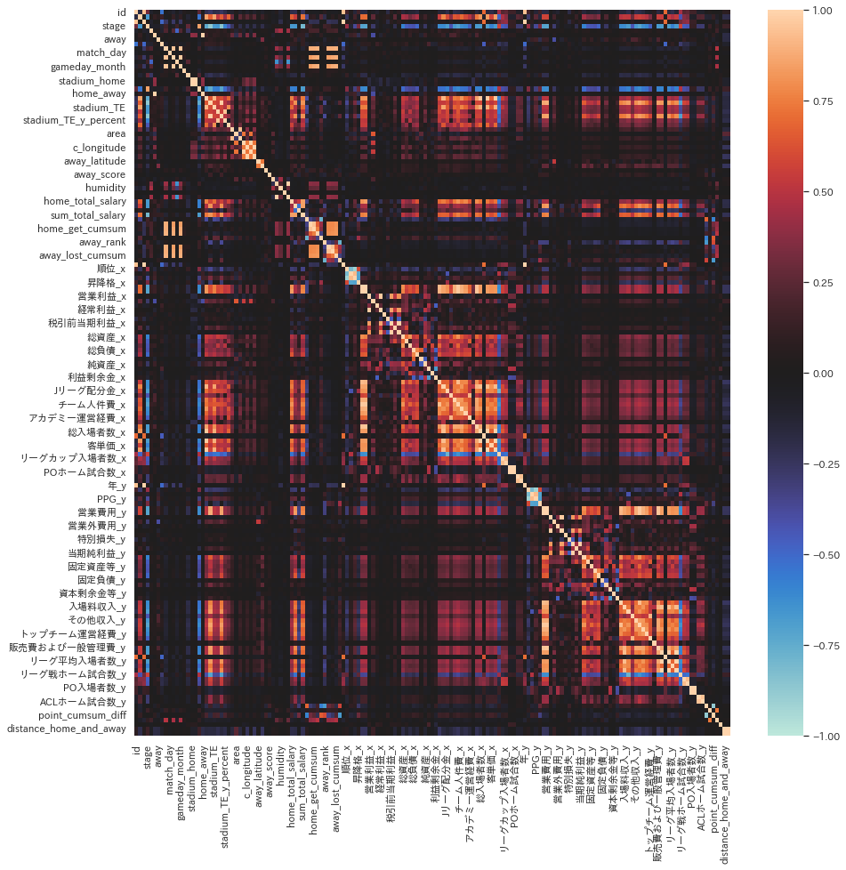

```python
# 相関係数を計算してヒートマップで可視化
df_corr = df_v_train.corr()
plt.figure(figsize=(15, 15))
sns.heatmap(df_corr, vmax=1, vmin=-1, center=0)
```

```python
# 目的変数との相関が高い特徴量を確認
abs(df_corr['y']).sort_values(ascending=False)
```

```
y                            1.000000
home_TE                      0.861646
stadium_TE                   0.855068
リーグ戦入場者数_x                   0.837684
リーグ平均入場者数_x                  0.835068
総入場者数_x                      0.828098
入場料収入_x                      0.780693
販売費および一般管理費_x                0.731009
sum_total_salary             0.721809
営業費用_x                       0.705228
試合関連経費_x                     0.702270
営業収入_x                       0.699218
capa                         0.684865
home_total_salary            0.669133
stage                        0.668457
away_TE                      0.668344
away_TE_y_percent            0.656467
その他収入_x                      0.640796
チーム人件費_x                     0.617051
Jリーグ配分金_x                    0.598800
トップチーム運営経費_x                 0.597127
営業費用_y                       0.576638
営業収入_y                       0.570567
客単価_x                        0.568014
チーム人件費_y                     0.561489
販売費および一般管理費_y                0.553725
away_total_salary            0.551908
リーグ平均入場者数_y                  0.542405
stage_match                  0.542336
広告料収入_x                      0.540304
総入場者数_y                      0.539376
その他収入_y                      0.534606
リーグ戦入場者数_y                   0.532875
試合関連経費_y                     0.528251
入場料収入_y                      0.525297
Jリーグ配分金_y                    0.519689
home_TE_y_percent            0.518041
アカデミー運営経費_x                  0.504287
広告料収入_y                      0.495214
リーグ戦ホーム試合数_x                 0.487765
```

[output cut: 107 more lines]

```
away_score                   0.018340
match_day                    0.013118
away_lost_cumsum             0.009334
当期純利益_x                      0.007986
distance_stadium_and_home    0.006810
away_point_cumsum            0.006105
gameday_date                 0.004352
area                         0.004248
年_x                          0.003469
year                         0.002161
経常利益_y                       0.002127
当期純利益_y                      0.001082
referee                      0.000783
年_y                          0.000730
Name: y, dtype: float64
```

```python
# ターゲットエンコーディングの特徴量を一部削除
# drop_cols.extend(['home_TE', 'stadium_TE', 'away_TE_y_percent'])
```

## スタジアムの分析

```python
df_v_train = df_v_train.sort_values('stadium')
```

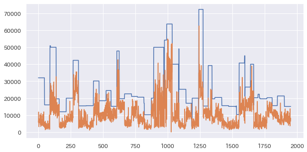

```python
# スタジアムのキャパシティに対する観客動員数の推移
plt.figure(figsize=(10, 5))
ax = plt.gca()
ax.plot(df_v_train['capa'].values)
ax.plot(df_v_train['y'].values)
plt.show()
```

```
ベストアメニティスタジアム
```

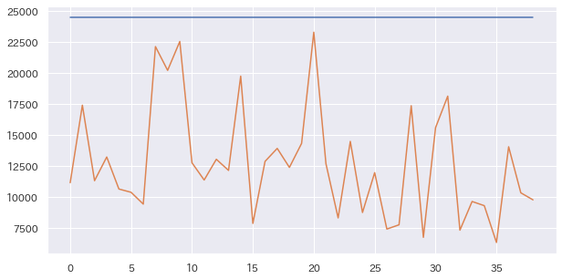

```python
# ランダムに1つのスタジアムの観客動員数を描画
plt.figure(figsize=(10, 5))
ax = plt.gca()
s = random.choice(df_v_train['stadium'].unique())
df_part = df_v_train[df_v_train['stadium']==s]
ax.plot(df_part['capa'].values)
ax.plot(df_part['y'].values)
print(s)
plt.show()
```

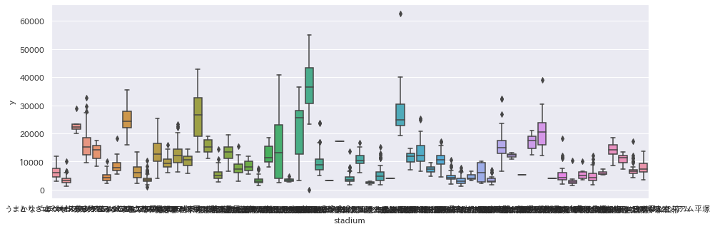

```python
# スタジアム毎の箱ひげ図を描画
plt.figure(figsize=(15, 5))
sns.boxplot(x="stadium", y="y", data=df_v_train)
plt.show()
```

# J1/J2 in a model

## Prepare Dataset

機械学習モデルにインプットするデータセットを用意します。

### 欠損値補完

マージで発生した欠損値を補完します。

```python
# 欠損値が含まれる列名を取得
isnull_cols = list(df.T[df.isnull().any()].index)
# 目的変数yを除外
isnull_cols.remove('y')
# 中央値で欠損値補完
df[isnull_cols] = df[isnull_cols].fillna(df.median())
```

### Drop Columns

不要列を削除する。

```python
print(f'削除前: df.shape={df.shape}')
df.drop(drop_cols, axis=1, inplace=True)
print(f'削除後: df.shape={df.shape}')
```

```
削除前: df.shape=(2304, 196)
削除後: df.shape=(2304, 151)
```

### 別目的変数を作成

```python
# 観客収容率を別の目的変数として追加
df['y_percent'] = df['y']/df['capa']*100
```

### データ分割

```python
# 学習用データ -> yがNaNではないデータ
df_train = df[~df['y'].isnull()].reset_index(drop=True)
print(f'Shape of df_train is ',df_train.shape)
```

```
Shape of df_train is  (1953, 152)
```

```python
# テスト用データ -> yがNaNのデータ
df_test = df[df['y'].isnull()].reset_index(drop=True)
print(f'Shape of df_test is ',df_test.shape)
```

```
Shape of df_test is  (351, 152)
```

### 特徴量設定

```python
# 特徴量リスト（不要を除くフルリスト）
feature = list(df_train.columns)
for i in ['id', 'y', 'y_percent', 'stadium']:
    if i in feature:
        feature.remove(i)

# カテゴリ特徴量リスト（アルゴリズムによってダミー化/One-Hotエンコーディングをすべき特徴量）
categorical_feature = [
  'stage', 'home', 'away', 'match_day', 'gameday_day', 'weather', 'referee',
  'stadium_home', 'stadium_away', 'stage_match', 'home_away', 'match_section_bins'
  ]

# One-Hotエンコーディングできない特徴量を除外した特徴量リスト（testにしか含まれていないカテゴリが存在）
categorical_feature_oh = categorical_feature.copy()
for i in ['stadium_home', 'stadium_away', 'home_away']:
    if i in categorical_feature_oh:
        categorical_feature_oh.remove(i)

# TV放送データフレームの列名 -> 列数が多いわりに情報が少なく精度が下がるため除外
# categorical_feature.extend(list(tv_table.columns))
```

```python
# 特徴量リスト - Feature Selection(Lasso)で選定
selected_feature_Lasso = ['stage',
 'time',
 'home',
 'away',
 'tv',
 'match_section',
 'match_day',
 'match_section_bins',
 'gameday_month',
 'gameday_date',
 'gameday_day',
 'stadium_home',
 'stadium_away',
 'stage_match',
 'home_away',
 'home_TE',
 'away_TE',
 'stadium_TE',
 'home_TE_y_percent',
 'away_TE_y_percent',
 'stadium_TE_y_percent',
 'capa',
 'population',
 'area',
 'dencity',
 'weather',
 'temperature',
 'humidity',
 'referee',
 'THI',
 'home_total_salary',
 'away_total_salary',
 'sum_total_salary',
 'home_rank',
 'home_point_cumsum',
 'home_lost_cumsum',
 'home_diff_cumsum',
 'away_rank',
 'away_lost_cumsum',
 'away_diff_cumsum',
 '順位_x',
 '勝ち点_x',
 'PPG_x',
 '昇降格_x',
 '営業収入_x',
 '営業利益_x',
 '営業外収益_x',
 '営業外費用_x',
 '経常利益_x',
 '特別利益_x',
 '特別損失_x',
 '法人税および住民税等_x',
 '当期純利益_x',
 '流動資産_x',
 '固定資産等_x',
 '流動負債_x',
 '固定負債_x',
 '資本金_x',
 '資本剰余金等_x',
 '入場料収入_x',
 'Jリーグ配分金_x',
 'アカデミー関連収入_x',
 'その他収入_x',
 'チーム人件費_x',
 '試合関連経費_x',
 'トップチーム運営経費_x',
 '女子チーム運営経費_x',
 '販売費および一般管理費_x',
 '総入場者数_x',
 'ホーム総試合数_x',
 '客単価_x',
 'リーグ戦入場者数_x',
 'リーグ戦ホーム試合数_x',
 'PO入場者数_x',
 'POホーム試合数_x',
 'ACL入場者数_x',
 'ACLホーム試合数_x',
 '順位_y',
 '勝ち点_y',
 'PPG_y',
 '昇降格_y',
 '営業収入_y',
 '営業費用_y',
 '営業外収益_y',
 '営業外費用_y',
 '特別利益_y',
 '特別損失_y',
 '税引前当期利益_y',
 '法人税および住民税等_y',
 '固定資産等_y',
 '総負債_y',
 '流動負債_y',
 '純資産_y',
 '資本金_y',
 '資本剰余金等_y',
 '広告料収入_y',
 '入場料収入_y',
 'Jリーグ配分金_y',
 'アカデミー関連収入_y',
 'その他収入_y',
 'チーム人件費_y',
 '試合関連経費_y',
 'アカデミー運営経費_y',
 '女子チーム運営経費_y',
 '販売費および一般管理費_y',
 '総入場者数_y',
 'ホーム総試合数_y',
 'リーグ平均入場者数_y',
 '客単価_y',
 'リーグ戦入場者数_y',
 'リーグ戦ホーム試合数_y',
 'リーグカップ入場者数_y',
 'リーグカップホーム試合数_y',
 'POホーム試合数_y',
 'ACL入場者数_y',
 'ACLホーム試合数_y',
 'rank_diff_abs',
 'point_cumsum_diff',
 'point_cumsum_diff_abs',
 'distance_stadium_and_home',
 'distance_home_and_away',
 'distance_away_and_stadium']

# カテゴリ特徴量リスト（アルゴリズムによってダミー化/One-Hotエンコーディングをすべき特徴量）
categorical_selected_feature_Lasso = [
  'stage', 'home', 'away', 'match_day', 'gameday_day', 'weather', 'referee',
  'stadium_home', 'stadium_away', 'stage_match', 'home_away', 'match_section_bins'
  ]
categorical_selected_feature_Lasso = [i for i in selected_feature_Lasso if i in categorical_selected_feature_Lasso]

# One-Hotエンコーディングできない特徴量を除外した特徴量リスト（testにしか含まれていないカテゴリが存在）
categorical_selected_feature_Lasso_oh = categorical_selected_feature_Lasso.copy()
for i in ['stadium_home', 'stadium_away', 'home_away']:
    if i in categorical_selected_feature_Lasso_oh:
        categorical_selected_feature_Lasso_oh.remove(i)

# TV放送データフレームの列名 -> 列数が多いわりに情報が少なく精度が下がるため除外
# categorical_selected_feature_Lasso.extend(list(tv_table.columns))
```

```python
# 特徴量リスト - Feature Selection(Boruta)で選定
selected_feature_Boruta = ['away_TE_y_percent',
 'home_diff_cumsum',
 'home_point_cumsum',
 'sum_total_salary',
 '試合関連経費_x',
 '販売費および一般管理費_x',
 'dencity',
 '総入場者数_x',
 'population',
 'capa',
 'リーグ平均入場者数_x',
 '客単価_x',
 'stadium_TE',
 'away_TE',
 'home_TE',
 'away_point_cumsum',
 '客単価_y',
 'リーグ戦入場者数_x',
 'home_away',
 'トップチーム運営経費_y',
 'match_section_symmetry',
 'チーム人件費_y',
 '試合関連経費_y',
 'stage_match',
 'home_get_cumsum',
 'diff_total_salary',
 'Jリーグ配分金_x',
 '営業収入_y',
 'stadium_away',
 '固定負債_x',
 '入場料収入_x',
 'match_section',
 'away_total_salary',
 'home',
 'distance_away_and_stadium',
 '流動資産_x',
 'リーグ平均入場者数_y',
 '入場料収入_y',
 'away_diff_cumsum',
 'home_rank',
 '営業費用_x',
 '営業費用_y',
 'stage',
 'distance_home_and_away',
 'その他収入_y',
 'アカデミー運営経費_x',
 'humidity',
 '固定資産等_x',
 '営業収入_x',
 'stadium_TE_y_percent',
 'Jリーグ配分金_y',
 'away_get_cumsum',
 'アカデミー関連収入_y',
 '広告料収入_y',
 '女子チーム運営経費_x',
 '広告料収入_x',
 '利益剰余金_x',
 'チーム人件費_x',
 '販売費および一般管理費_y',
 '営業利益_x',
 'リーグ戦入場者数_y',
 '流動負債_y',
 'time',
 'gameday_day',
 '経常利益_x',
 'アカデミー関連収入_x',
 'home_total_salary',
 '利益剰余金_y',
 '総入場者数_y',
 'home_lost_cumsum',
 '営業外収益_y',
 '法人税および住民税等_x',
 'home_TE_y_percent',
 'away_rank',
 'リーグカップ入場者数_y',
 'THI',]

# カテゴリ特徴量リスト（アルゴリズムによってダミー化/One-Hotエンコーディングをすべき特徴量）
categorical_selected_feature_Boruta = [
  'stage', 'home', 'away', 'match_day', 'gameday_day', 'weather', 'referee',
  'stadium_home', 'stadium_away', 'stage_match', 'home_away', 'match_section_bins'
  ]
categorical_selected_feature_Boruta = [i for i in selected_feature_Boruta if i in categorical_selected_feature_Boruta]

# One-Hotエンコーディングできない特徴量を除外した特徴量リスト（testにしか含まれていないカテゴリが存在）
categorical_selected_feature_Boruta_oh = categorical_selected_feature_Boruta.copy()
for i in ['stadium_home', 'stadium_away', 'home_away']:
    if i in categorical_selected_feature_Boruta_oh:
        categorical_selected_feature_Boruta_oh.remove(i)

# TV放送データフレームの列名 -> 列数が多いわりに情報が少なく精度が下がるため除外
# categorical_selected_feature_Boruta.extend(list(tv_table.columns))
```

### 学習パラメータ設定

```python
# 目的変数
# TARGET = 'y_percent'
TARGET = 'y'

# コメントアウトの場合はすべての特徴量を使用
# feature = selected_feature_Boruta
# categorical_feature = categorical_selected_feature_Boruta
# categorical_feature_oh = categorical_selected_feature_Boruta_oh

# 学習方法
train_params = {
    'train_df': df_train,
    'test_df': df_test,
    'objective': TARGET,
    'features': feature,
    'categoricals': categorical_feature,
    'n_splits': 5,
    'cv_method': 'KFold',
    # 'cv_method': 'TimeSeriesSplit',
    # 'cv_method': 'GroupKFold',
    # 'group': 'stadium',
    }

train_params_oh = {
    'train_df': df_train,
    'test_df': df_test,
    'objective': TARGET,
    'features': feature,
    'categoricals': categorical_feature_oh,
    'n_splits': 5,
    'cv_method': 'KFold',
    # 'cv_method': 'TimeSeriesSplit',
    # 'cv_method': 'GroupKFold',
    # 'group': 'stadium',
    }
```

## Train Single Model

シングルモデルで機械学習を行います。

### LightGBM

```python
# パラメータ設定
params = {
    # 最適化結果
    'learning_rate': 0.02099999088056449,
    'max_depth': 2,

    'boosting_type': 'gbdt',
    'objective': 'regression',
    'metric': 'rmse',
    'random_state': random_seed,
    'n_estimators': 10000,
    'early_stopping_rounds': 100,
    'verbose': -1,
    'n_jobs': -1
    }
```

```python
# 学習・予測
model = Lgb_Model(**train_params, params=params)
if TARGET == 'y_percent' : print(f"RMSE Score: {rmse(df_train['y'], df_train['capa']*model.oof_pred/100):.4f}")
```

```
<bound method Lgb_Model.train_model of <__main__.Lgb_Model object at 0x0000024293517A48>>
--------------------------------------------------------------------------------
Training until validation scores don't improve for 100 rounds
Early stopping, best iteration is:
[1619]	training's rmse: 1664.53	valid_1's rmse: 3276.93
 ==>> [Fold-0] 2021-09-21 12:39:46.534814
        train's rmse: 1664.5325  valid's rmse: 3276.9282
--------------------------------------------------------------------------------
Training until validation scores don't improve for 100 rounds
Early stopping, best iteration is:
[1858]	training's rmse: 1637.95	valid_1's rmse: 2573.38
 ==>> [Fold-1] 2021-09-21 12:39:47.141951
        train's rmse: 1637.9500  valid's rmse: 2573.3769
--------------------------------------------------------------------------------
Training until validation scores don't improve for 100 rounds
Early stopping, best iteration is:
[1085]	training's rmse: 1898.02	valid_1's rmse: 2672.57
 ==>> [Fold-2] 2021-09-21 12:39:47.535039
        train's rmse: 1898.0151  valid's rmse: 2672.5731
--------------------------------------------------------------------------------
Training until validation scores don't improve for 100 rounds
Early stopping, best iteration is:
[736]	training's rmse: 2096.15	valid_1's rmse: 2717.6
 ==>> [Fold-3] 2021-09-21 12:39:47.822104
        train's rmse: 2096.1460  valid's rmse: 2717.6019
--------------------------------------------------------------------------------
Training until validation scores don't improve for 100 rounds
Early stopping, best iteration is:
[1363]	training's rmse: 1657.72	valid_1's rmse: 3294.3
 ==>> [Fold-4] 2021-09-21 12:39:48.302212
        train's rmse: 1657.7201  valid's rmse: 3294.3004
================================================================================
All Fold -> Our oof rmse is: 2923.6288
```

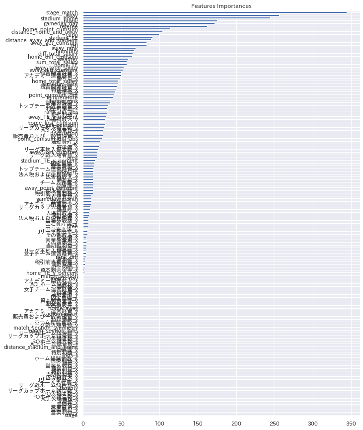

```python
%matplotlib inline
ShowFeatureImportance(model.model.feature_importance(), feature, (10,15))
```

```python
# 学習用データの予測結果（Out-of-fold）
oof = pd.DataFrame(model.oof_pred)

# テスト用データの予測結果
pred = pd.DataFrame(model.y_pred)
CheckDF(pred)
```

|  | 欠損数 | 欠-% | 0数 | 0-% | 最小 | 最大 | 中央 | 平均 | 標準偏差 | 種類 |
| --- | --- | --- | --- | --- | --- | --- | --- | --- | --- | --- |
| 0 | 0 | 0.0 | 0 | 0.0 | 2667.323303 | 49173.208224 | 9454.481297 | 11821.951833 | 8075.597089 | float64 |

```python
## 後処理
if TARGET == 'y':
    # 予測数が学習データの最小数より小さい場合、またはスタジアムのキャパシティより大きい場合、それぞれ置換
    mask_min = pred[0]<df_train['y'].min()
    mask_max = pred[0]>df_test['capa']
    print(f'[Before] Too few: {mask_min.sum()}  Too many: {mask_max.sum()}')

    pred[0] = pred[0].where(~mask_min, df_train['y'].min())
    pred[0] = pred[0].where(~mask_max, df_test['capa'])
    mask_min = pred[0]<df_train['y'].min()
    mask_max = pred[0]>df_test['capa']
    print(f'[After]  Too few: {mask_min.sum()}  Too many: {mask_max.sum()}')

elif TARGET == 'y_percent':
    # 予測数が学習データの最小数より小さい場合、またはスタジアムのキャパシティより大きい場合、それぞれ置換
    mask_min = pred[0]<0
    mask_max = pred[0]>100
    print(f'[Before] Too few: {mask_min.sum()}  Too many: {mask_max.sum()}')

    pred[0] = pred[0].where(~mask_min, 0)
    pred[0] = pred[0].where(~mask_max, 100)
    mask_min = pred[0]<0
    mask_max = pred[0]>100
    print(f'[After]  Too few: {mask_min.sum()}  Too many: {mask_max.sum()}')
```

```
[Before] Too few: 0  Too many: 3
[After]  Too few: 0  Too many: 0
```

```python
# idを絞ってSubmit形式に成形
all_test_y = pd.concat([df_test['id'], pred], axis=1)
submit = pd.merge(sample_submit['id'], all_test_y, on='id')
display(submit.head())
```

|  | id | 0 |
| --- | --- | --- |
| 0 | 15822 | 14505.979512 |
| 1 | 15823 | 20435.786220 |
| 2 | 15824 | 36564.064950 |
| 3 | 15825 | 13537.856817 |
| 4 | 15827 | 32999.972449 |

```python
# 出力
suffix = datetime.datetime.now().strftime("%Y%m%d%H%M") + '.csv'
submit.to_csv(f'{full_path}output/submission/submission_lgb_{suffix}', index=None, header=False)
oof.to_csv(f'{full_path}output/oof/oof_lgb_{suffix}', index=None, header=False)
```

```python
# アンサンブル学習用データ
val_lgb = oof.copy()
test_lgb = pred.copy()
```

### XGBoost

```python
# パラメータ設定
params = {
    # 最適化結果
    'depth': 1,
    'learning_rate': 0.04936432589608176,

    'objective': 'reg:squarederror',
    'eval_metric': 'rmse',
    'random_state': random_seed,
    'n_estimators': 10000,
    'early_stopping_rounds': 100,
    'verbose': 100,
    'n_jobs': -1
    }
```

```python
# 学習・予測
model = Xgb_Model(**train_params, params=params)
if TARGET == 'y_percent' : print(f"RMSE Score: {rmse(df_train['y'], df_train['capa']*model.oof_pred/100):.4f}")
```

[output not shown]

```python
# 学習・予測
model = Xgb_Model(**train_params, params=params)
if TARGET == 'y_percent' : print(f"RMSE Score: {rmse(df_train['y'], df_train['capa']*model.oof_pred/100):.4f}")
```

[output not shown]

```python
# 学習・予測
model = Xgb_Model(**train_params, params=params)
if TARGET == 'y_percent' : print(f"RMSE Score: {rmse(df_train['y'], df_train['capa']*model.oof_pred/100):.4f}")
```

[output not shown]

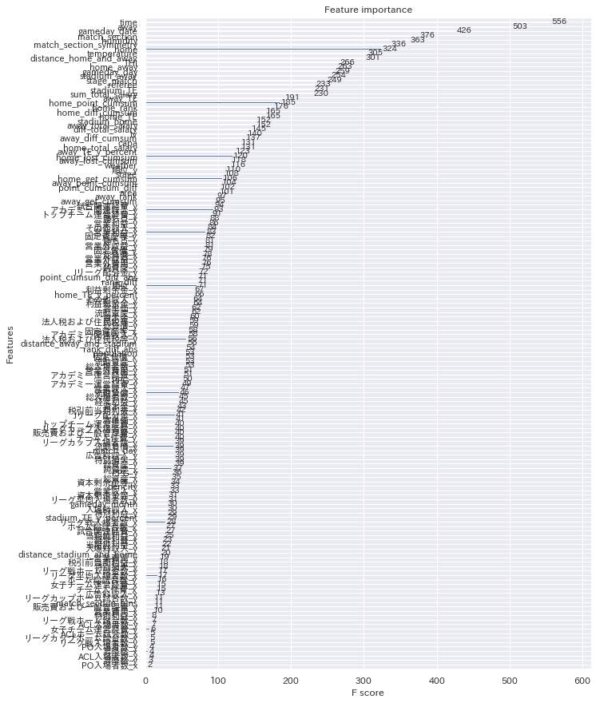

```python
%matplotlib inline
_, ax = plt.subplots(figsize=(10, 15))
xgb.plot_importance(model.model, ax=ax)
```

```python
# 学習用データの予測結果（Out-of-fold）
oof = pd.DataFrame(model.oof_pred)

# テスト用データの予測結果
pred = pd.DataFrame(model.y_pred)
CheckDF(pred)
```

|  | 欠損数 | 欠-% | 0数 | 0-% | 最小 | 最大 | 中央 | 平均 | 標準偏差 | 種類 |
| --- | --- | --- | --- | --- | --- | --- | --- | --- | --- | --- |
| 0 | 0 | 0.0 | 0 | 0.0 | 2416.175934 | 51530.943359 | 9735.456299 | 11834.287828 | 8112.429602 | float64 |

```python
## 後処理
if TARGET == 'y':
    # 予測数が学習データの最小数より小さい場合、またはスタジアムのキャパシティより大きい場合、それぞれ置換
    mask_min = pred[0]<df_train['y'].min()
    mask_max = pred[0]>df_test['capa']
    print(f'[Before] Too few: {mask_min.sum()}  Too many: {mask_max.sum()}')

    pred[0] = pred[0].where(~mask_min, df_train['y'].min())
    pred[0] = pred[0].where(~mask_max, df_test['capa'])
    mask_min = pred[0]<df_train['y'].min()
    mask_max = pred[0]>df_test['capa']
    print(f'[After]  Too few: {mask_min.sum()}  Too many: {mask_max.sum()}')

elif TARGET == 'y_percent':
    # 予測数が学習データの最小数より小さい場合、またはスタジアムのキャパシティより大きい場合、それぞれ置換
    mask_min = pred[0]<0
    mask_max = pred[0]>100
    print(f'[Before] Too few: {mask_min.sum()}  Too many: {mask_max.sum()}')

    pred[0] = pred[0].where(~mask_min, 0)
    pred[0] = pred[0].where(~mask_max, 100)
    mask_min = pred[0]<0
    mask_max = pred[0]>100
    print(f'[After]  Too few: {mask_min.sum()}  Too many: {mask_max.sum()}')
```

```
[Before] Too few: 0  Too many: 2
[After]  Too few: 0  Too many: 0
```

```python
# idを絞ってSubmit形式に成形
all_test_y = pd.concat([df_test['id'], pred], axis=1)
submit = pd.merge(sample_submit['id'], all_test_y, on='id')
display(submit.head())
```

|  | id | 0 |
| --- | --- | --- |
| 0 | 15822 | 13363.769043 |
| 1 | 15823 | 17035.280762 |
| 2 | 15824 | 36898.659668 |
| 3 | 15825 | 12646.691162 |
| 4 | 15827 | 31440.652832 |

```python
# 出力
suffix = datetime.datetime.now().strftime("%Y%m%d%H%M") + '.csv'
submit.to_csv(f'{full_path}output/submission/submission_xgb_{suffix}', index=None, header=False)
oof.to_csv(f'{full_path}output/oof/oof_xgb_{suffix}', index=None, header=False)
```

```python
# アンサンブル学習用データ
val_xgb = oof.copy()
test_xgb = pred.copy()
```

### CatBoost

```python
# パラメータ設定
params = {
    # 最適化結果
    'bagging_temperature': 0.46680649677821706,
    'depth': 2,
    'has_time': True,
    'learning_rate': 0.12067904687956403,
    'random_strength': 8,

    'loss_function': 'RMSE',
    'use_best_model': True,
    'random_state': random_seed,
    'num_boost_round': 10000,
    'early_stopping_rounds': 100,
    'verbose': 100,
    'is_probability': False,
    }
if env == 'Colab':
    params['task_type'] = 'GPU'
```

```python
# 学習・予測
model = Cgb_Model(**train_params, params=params)
if TARGET == 'y_percent' : print(f"RMSE Score: {rmse(df_train['y'], df_train['capa']*model.oof_pred/100):.4f}")
```

```
<bound method Cgb_Model.train_model of <__main__.Cgb_Model object at 0x0000024293A37C08>>
--------------------------------------------------------------------------------
0:	learn: 7437.2874160	test: 8737.4288106	best: 8737.4288106 (0)	total: 24.4ms	remaining: 4m 4s
100:	learn: 3016.5816507	test: 4016.9804287	best: 4014.2409206 (98)	total: 963ms	remaining: 1m 34s
200:	learn: 2768.5165564	test: 3821.2181772	best: 3821.2181772 (200)	total: 1.95s	remaining: 1m 35s
300:	learn: 2625.5702494	test: 3696.3649912	best: 3695.8555346 (295)	total: 2.98s	remaining: 1m 35s
400:	learn: 2431.7135757	test: 3579.1953546	best: 3579.1080973 (399)	total: 3.99s	remaining: 1m 35s
500:	learn: 2367.7000191	test: 3530.1456206	best: 3530.1456206 (500)	total: 5.01s	remaining: 1m 34s
600:	learn: 2303.5310378	test: 3489.2957072	best: 3489.2957072 (600)	total: 6.03s	remaining: 1m 34s
700:	learn: 2212.4665988	test: 3429.3422960	best: 3429.2796735 (699)	total: 7.05s	remaining: 1m 33s
800:	learn: 2101.9094691	test: 3389.9684115	best: 3386.8922601 (776)	total: 8.06s	remaining: 1m 32s
900:	learn: 2037.2166496	test: 3376.8358621	best: 3374.7916529 (871)	total: 9.07s	remaining: 1m 31s
bestTest = 3374.791653
bestIteration = 871
Shrink model to first 872 iterations.
 ==>> [Fold-0] 2021-09-21 12:40:48.083681
        train's rmse: 2205.6832  valid's rmse: 3374.7929
--------------------------------------------------------------------------------
0:	learn: 7787.0965544	test: 7355.6023780	best: 7355.6023780 (0)	total: 10.6ms	remaining: 1m 46s
100:	learn: 3338.9658791	test: 3262.9216412	best: 3252.3718451 (73)	total: 933ms	remaining: 1m 31s
200:	learn: 3294.3761896	test: 3204.1454479	best: 3204.1454479 (200)	total: 1.88s	remaining: 1m 31s
300:	learn: 3047.0791354	test: 3051.6180204	best: 3051.6180204 (300)	total: 2.9s	remaining: 1m 33s
400:	learn: 2773.1323346	test: 2959.9538809	best: 2958.1280042 (396)	total: 3.91s	remaining: 1m 33s
500:	learn: 2612.5091142	test: 2860.0922633	best: 2859.2754756 (486)	total: 4.92s	remaining: 1m 33s
600:	learn: 2418.6617182	test: 2835.6484944	best: 2829.9256929 (583)	total: 5.93s	remaining: 1m 32s
700:	learn: 2286.7213103	test: 2821.4738707	best: 2819.1328772 (699)	total: 6.95s	remaining: 1m 32s
800:	learn: 2183.2511555	test: 2812.9869954	best: 2808.5652844 (762)	total: 8s	remaining: 1m 31s
900:	learn: 2107.0249867	test: 2819.1529663	best: 2794.3269676 (823)	total: 9s	remaining: 1m 30s
bestTest = 2794.326968
bestIteration = 823
Shrink model to first 824 iterations.
 ==>> [Fold-1] 2021-09-21 12:40:57.813813
        train's rmse: 2259.1234  valid's rmse: 2794.3265
--------------------------------------------------------------------------------
0:	learn: 7773.5799336	test: 7384.6942563	best: 7384.6942563 (0)	total: 11.4ms	remaining: 1m 54s
100:	learn: 3257.6066531	test: 3041.8995277	best: 3041.8995277 (100)	total: 929ms	remaining: 1m 31s
200:	learn: 3060.1811701	test: 2950.5036581	best: 2950.5036581 (200)	total: 1.86s	remaining: 1m 30s
300:	learn: 2803.6389158	test: 2840.6655176	best: 2840.6655176 (300)	total: 2.86s	remaining: 1m 32s
400:	learn: 2603.6790989	test: 2777.3800236	best: 2776.6650589 (390)	total: 3.87s	remaining: 1m 32s
500:	learn: 2444.7637299	test: 2773.0495756	best: 2761.5882453 (486)	total: 4.89s	remaining: 1m 32s
```

[output cut: 19 more lines]

```
0:	learn: 7734.4878790	test: 7607.8760377	best: 7607.8760377 (0)	total: 10.5ms	remaining: 1m 45s
100:	learn: 3185.5567589	test: 3864.9690774	best: 3864.9690774 (100)	total: 934ms	remaining: 1m 31s
200:	learn: 2852.2373820	test: 3717.8839308	best: 3716.3034294 (196)	total: 1.87s	remaining: 1m 31s
300:	learn: 2558.9854676	test: 3647.2733419	best: 3640.4586017 (292)	total: 2.86s	remaining: 1m 32s
400:	learn: 2375.8577587	test: 3597.9413829	best: 3593.8333965 (370)	total: 3.86s	remaining: 1m 32s
500:	learn: 2271.9783730	test: 3555.1187971	best: 3553.0277100 (494)	total: 4.88s	remaining: 1m 32s
600:	learn: 2162.8126234	test: 3546.5901052	best: 3537.6104002 (529)	total: 5.88s	remaining: 1m 32s
700:	learn: 2085.6710524	test: 3536.7463651	best: 3527.8614311 (634)	total: 6.89s	remaining: 1m 31s
bestTest = 3527.861431
bestIteration = 634
Shrink model to first 635 iterations.
 ==>> [Fold-4] 2021-09-21 12:41:17.884930
        train's rmse: 2198.6082  valid's rmse: 3527.8629
================================================================================
All Fold -> Our oof rmse is: 3116.5910
```

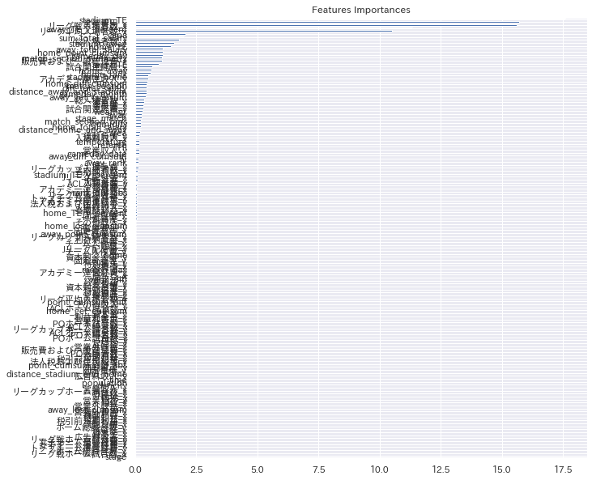

```python
%matplotlib inline
ShowFeatureImportance(model.model.get_feature_importance(), feature, size=(10,10))
```

```python
# 学習用データの予測結果（Out-of-fold）
oof = pd.DataFrame(model.oof_pred)

# テスト用データの予測結果
pred = pd.DataFrame(model.y_pred)
CheckDF(pred)
```

|  | 欠損数 | 欠-% | 0数 | 0-% | 最小 | 最大 | 中央 | 平均 | 標準偏差 | 種類 |
| --- | --- | --- | --- | --- | --- | --- | --- | --- | --- | --- |
| 0 | 0 | 0.0 | 0 | 0.0 | 2761.295304 | 46149.81131 | 9652.83013 | 11850.304738 | 8005.507251 | float64 |

```python
## 後処理
if TARGET == 'y':
    # 予測数が学習データの最小数より小さい場合、またはスタジアムのキャパシティより大きい場合、それぞれ置換
    mask_min = pred[0]<df_train['y'].min()
    mask_max = pred[0]>df_test['capa']
    print(f'[Before] Too few: {mask_min.sum()}  Too many: {mask_max.sum()}')

    pred[0] = pred[0].where(~mask_min, df_train['y'].min())
    pred[0] = pred[0].where(~mask_max, df_test['capa'])
    mask_min = pred[0]<df_train['y'].min()
    mask_max = pred[0]>df_test['capa']
    print(f'[After]  Too few: {mask_min.sum()}  Too many: {mask_max.sum()}')

elif TARGET == 'y_percent':
    # 予測数が学習データの最小数より小さい場合、またはスタジアムのキャパシティより大きい場合、それぞれ置換
    mask_min = pred[0]<0
    mask_max = pred[0]>100
    print(f'[Before] Too few: {mask_min.sum()}  Too many: {mask_max.sum()}')

    pred[0] = pred[0].where(~mask_min, 0)
    pred[0] = pred[0].where(~mask_max, 100)
    mask_min = pred[0]<0
    mask_max = pred[0]>100
    print(f'[After]  Too few: {mask_min.sum()}  Too many: {mask_max.sum()}')
```

```
[Before] Too few: 0  Too many: 4
[After]  Too few: 0  Too many: 0
```

```python
# idを絞ってSubmit形式に成形
all_test_y = pd.concat([df_test['id'], pred], axis=1)
submit = pd.merge(sample_submit['id'], all_test_y, on='id')
display(submit.head())
```

|  | id | 0 |
| --- | --- | --- |
| 0 | 15822 | 14092.353052 |
| 1 | 15823 | 20496.598357 |
| 2 | 15824 | 34804.919193 |
| 3 | 15825 | 14037.326918 |
| 4 | 15827 | 33143.387849 |

```python
# 出力
suffix = datetime.datetime.now().strftime("%Y%m%d%H%M") + '.csv'
submit.to_csv(f'{full_path}output/submission/submission_cgb_{suffix}', index=None, header=False)
oof.to_csv(f'{full_path}output/oof/oof_cgb_{suffix}', index=None, header=False)
```

```python
# アンサンブル学習用データ
val_cgb = oof.copy()
test_cgb = pred.copy()
```

### ElasticNet

```python
# パラメータ設定
params = {
    # 最適化結果
    'alpha': 0.007975362105285334,
    'l1_ratio': 0.49623138599877586,

    'verbose': 100,
    }
```

```python
# 学習・予測
model = Lin_Model(**train_params_oh, params=params)
if TARGET == 'y_percent' : print(f"RMSE Score: {rmse(df_train['y'], df_train['capa']*model.oof_pred/100):.4f}")
```

```
<bound method Lin_Model.train_model of <__main__.Lin_Model object at 0x00000242935DAC48>>
--------------------------------------------------------------------------------
 ==>> [Fold-0] 2021-09-21 12:41:20.371988
        train's rmse: 2653.6084  valid's rmse: 3561.9258
--------------------------------------------------------------------------------
 ==>> [Fold-1] 2021-09-21 12:41:20.693768
        train's rmse: 2831.2164  valid's rmse: 2719.0727
--------------------------------------------------------------------------------
 ==>> [Fold-2] 2021-09-21 12:41:21.015840
        train's rmse: 2780.0970  valid's rmse: 2904.3593
--------------------------------------------------------------------------------
 ==>> [Fold-3] 2021-09-21 12:41:21.384923
        train's rmse: 2785.7586  valid's rmse: 2963.7025
--------------------------------------------------------------------------------
 ==>> [Fold-4] 2021-09-21 12:41:21.758007
        train's rmse: 2621.9687  valid's rmse: 3537.6383
================================================================================
All Fold -> Our oof rmse is: 3156.2914
```

```python
# 学習用データの予測結果（Out-of-fold）
oof = pd.DataFrame(model.oof_pred)

# テスト用データの予測結果
pred = pd.DataFrame(model.y_pred)
CheckDF(pred)
```

|  | 欠損数 | 欠-% | 0数 | 0-% | 最小 | 最大 | 中央 | 平均 | 標準偏差 | 種類 |
| --- | --- | --- | --- | --- | --- | --- | --- | --- | --- | --- |
| 0 | 0 | 0.0 | 0 | 0.0 | -141.94493 | 43382.496224 | 9993.409652 | 12130.008784 | 7686.52166 | float64 |

```python
## 後処理
if TARGET == 'y':
    # 予測数が学習データの最小数より小さい場合、またはスタジアムのキャパシティより大きい場合、それぞれ置換
    mask_min = pred[0]<df_train['y'].min()
    mask_max = pred[0]>df_test['capa']
    print(f'[Before] Too few: {mask_min.sum()}  Too many: {mask_max.sum()}')

    pred[0] = pred[0].where(~mask_min, df_train['y'].min())
    pred[0] = pred[0].where(~mask_max, df_test['capa'])
    mask_min = pred[0]<df_train['y'].min()
    mask_max = pred[0]>df_test['capa']
    print(f'[After]  Too few: {mask_min.sum()}  Too many: {mask_max.sum()}')

elif TARGET == 'y_percent':
    # 予測数が学習データの最小数より小さい場合、またはスタジアムのキャパシティより大きい場合、それぞれ置換
    mask_min = pred[0]<0
    mask_max = pred[0]>100
    print(f'[Before] Too few: {mask_min.sum()}  Too many: {mask_max.sum()}')

    pred[0] = pred[0].where(~mask_min, 0)
    pred[0] = pred[0].where(~mask_max, 100)
    mask_min = pred[0]<0
    mask_max = pred[0]>100
    print(f'[After]  Too few: {mask_min.sum()}  Too many: {mask_max.sum()}')
```

```
[Before] Too few: 1  Too many: 7
[After]  Too few: 0  Too many: 0
```

```python
# idを絞ってSubmit形式に成形
all_test_y = pd.concat([df_test['id'], pred], axis=1)
submit = pd.merge(sample_submit['id'], all_test_y, on='id')
display(submit.head())
```

|  | id | 0 |
| --- | --- | --- |
| 0 | 15822 | 13292.004479 |
| 1 | 15823 | 19618.162712 |
| 2 | 15824 | 36810.477488 |
| 3 | 15825 | 13359.671427 |
| 4 | 15827 | 32387.388392 |

```python
# 出力
suffix = datetime.datetime.now().strftime("%Y%m%d%H%M") + '.csv'
submit.to_csv(f'{full_path}output/submission/submission_liner_{suffix}', index=None, header=False)
oof.to_csv(f'{full_path}output/oof/oof_liner_{suffix}', index=None, header=False)
```

```python
# アンサンブル学習用データ
val_liner = oof.copy()
test_liner = pred.copy()
```

### DeepLearning

```python
# パラメータ設定
params = {
    # 最適化結果
    'learning_rate': 0.09007772748400744,
    'dropout_rate': 0.504454417403372,
    'layer1': 88.0,
    'layer2': 88.0,
    'layer3': 48.0,

    'epochs': 10000,
    'early_stopping_rounds': 20,
    'verbose': 0,  # 表示モード0/1/2
    }
```

```python
# 学習・予測
model = NnReg_Model(**train_params_oh, params=params)
if TARGET == 'y_percent' : print(f"RMSE Score: {rmse(df_train['y'], df_train['capa']*model.oof_pred/100):.4f}")
```

```
<bound method NnReg_Model.train_model of <__main__.NnReg_Model object at 0x000002429402C988>>
All Fold -> Our oof rmse is: 3218.4646
```

```python
# 学習用データの予測結果（Out-of-fold）
oof = pd.DataFrame(model.oof_pred)

# テスト用データの予測結果
pred = pd.DataFrame(model.y_pred)
CheckDF(pred)
```

|  | 欠損数 | 欠-% | 0数 | 0-% | 最小 | 最大 | 中央 | 平均 | 標準偏差 | 種類 |
| --- | --- | --- | --- | --- | --- | --- | --- | --- | --- | --- |
| 0 | 0 | 0.0 | 0 | 0.0 | 3594.200317 | 37817.366699 | 9447.077393 | 11473.510709 | 7608.784217 | float64 |

```python
## 後処理
if TARGET == 'y':
    # 予測数が学習データの最小数より小さい場合、またはスタジアムのキャパシティより大きい場合、それぞれ置換
    mask_min = pred[0]<df_train['y'].min()
    mask_max = pred[0]>df_test['capa']
    print(f'[Before] Too few: {mask_min.sum()}  Too many: {mask_max.sum()}')

    pred[0] = pred[0].where(~mask_min, df_train['y'].min())
    pred[0] = pred[0].where(~mask_max, df_test['capa'])
    mask_min = pred[0]<df_train['y'].min()
    mask_max = pred[0]>df_test['capa']
    print(f'[After]  Too few: {mask_min.sum()}  Too many: {mask_max.sum()}')

elif TARGET == 'y_percent':
    # 予測数が学習データの最小数より小さい場合、またはスタジアムのキャパシティより大きい場合、それぞれ置換
    mask_min = pred[0]<0
    mask_max = pred[0]>100
    print(f'[Before] Too few: {mask_min.sum()}  Too many: {mask_max.sum()}')

    pred[0] = pred[0].where(~mask_min, 0)
    pred[0] = pred[0].where(~mask_max, 100)
    mask_min = pred[0]<0
    mask_max = pred[0]>100
    print(f'[After]  Too few: {mask_min.sum()}  Too many: {mask_max.sum()}')
```

```
[Before] Too few: 0  Too many: 3
[After]  Too few: 0  Too many: 0
```

```python
# idを絞ってSubmit形式に成形
all_test_y = pd.concat([df_test['id'], pred], axis=1)
submit = pd.merge(sample_submit['id'], all_test_y, on='id')
display(submit.head())
```

|  | id | 0 |
| --- | --- | --- |
| 0 | 15822 | 14199.139404 |
| 1 | 15823 | 19995.362061 |
| 2 | 15824 | 34344.384766 |
| 3 | 15825 | 13919.722412 |
| 4 | 15827 | 34313.017090 |

```python
# 出力
suffix = datetime.datetime.now().strftime("%Y%m%d%H%M") + '.csv'
submit.to_csv(f'{full_path}output/submission/submission_nn_{suffix}', index=None, header=False)
oof.to_csv(f'{full_path}output/oof/oof_nn_{suffix}', index=None, header=False)
```

```python
# アンサンブル学習用データ
val_nn = oof.copy()
test_nn = pred.copy()
```

### SVM

```python
# パラメータ設定
params = {
    # 最適化結果
    'C': 71327.94039113991,
    'gamma': 0.014528267770143898,

    'verbose': 100,
    }
```

```python
# 学習・予測
model = Svr_Model(**train_params_oh, params=params)
if TARGET == 'y_percent' : print(f"RMSE Score: {rmse(df_train['y'], df_train['capa']*model.oof_pred/100):.4f}")
```

```
<bound method Svr_Model.train_model of <__main__.Svr_Model object at 0x000002430FA6CC88>>
--------------------------------------------------------------------------------
 ==>> [Fold-0] 2021-09-21 12:42:11.219360
        train's rmse: 1688.3399  valid's rmse: 3464.7266
--------------------------------------------------------------------------------
 ==>> [Fold-1] 2021-09-21 12:42:13.380846
        train's rmse: 1876.3211  valid's rmse: 2453.4149
--------------------------------------------------------------------------------
 ==>> [Fold-2] 2021-09-21 12:42:15.540332
        train's rmse: 1792.7654  valid's rmse: 2677.3243
--------------------------------------------------------------------------------
 ==>> [Fold-3] 2021-09-21 12:42:17.722823
        train's rmse: 1795.4331  valid's rmse: 2917.6869
--------------------------------------------------------------------------------
 ==>> [Fold-4] 2021-09-21 12:42:19.896312
        train's rmse: 1548.1802  valid's rmse: 3346.1325
================================================================================
All Fold -> Our oof rmse is: 2996.5534
```

```python
# 学習用データの予測結果（Out-of-fold）
oof = pd.DataFrame(model.oof_pred)

# テスト用データの予測結果
pred = pd.DataFrame(model.y_pred)
CheckDF(pred)
```

|  | 欠損数 | 欠-% | 0数 | 0-% | 最小 | 最大 | 中央 | 平均 | 標準偏差 | 種類 |
| --- | --- | --- | --- | --- | --- | --- | --- | --- | --- | --- |
| 0 | 0 | 0.0 | 0 | 0.0 | 350.041429 | 43615.161164 | 9207.58562 | 11596.104815 | 7867.828924 | float64 |

```python
## 後処理
if TARGET == 'y':
    # 予測数が学習データの最小数より小さい場合、またはスタジアムのキャパシティより大きい場合、それぞれ置換
    mask_min = pred[0]<df_train['y'].min()
    mask_max = pred[0]>df_test['capa']
    print(f'[Before] Too few: {mask_min.sum()}  Too many: {mask_max.sum()}')

    pred[0] = pred[0].where(~mask_min, df_train['y'].min())
    pred[0] = pred[0].where(~mask_max, df_test['capa'])
    mask_min = pred[0]<df_train['y'].min()
    mask_max = pred[0]>df_test['capa']
    print(f'[After]  Too few: {mask_min.sum()}  Too many: {mask_max.sum()}')

elif TARGET == 'y_percent':
    # 予測数が学習データの最小数より小さい場合、またはスタジアムのキャパシティより大きい場合、それぞれ置換
    mask_min = pred[0]<0
    mask_max = pred[0]>100
    print(f'[Before] Too few: {mask_min.sum()}  Too many: {mask_max.sum()}')

    pred[0] = pred[0].where(~mask_min, 0)
    pred[0] = pred[0].where(~mask_max, 100)
    mask_min = pred[0]<0
    mask_max = pred[0]>100
    print(f'[After]  Too few: {mask_min.sum()}  Too many: {mask_max.sum()}')
```

```
[Before] Too few: 0  Too many: 2
[After]  Too few: 0  Too many: 0
```

```python
# idを絞ってSubmit形式に成形
all_test_y = pd.concat([df_test['id'], pred], axis=1)
submit = pd.merge(sample_submit['id'], all_test_y, on='id')
display(submit.head())
```

|  | id | 0 |
| --- | --- | --- |
| 0 | 15822 | 14655.079196 |
| 1 | 15823 | 19923.609593 |
| 2 | 15824 | 35964.271610 |
| 3 | 15825 | 13496.500389 |
| 4 | 15827 | 31873.446159 |

```python
# 出力
suffix = datetime.datetime.now().strftime("%Y%m%d%H%M") + '.csv'
submit.to_csv(f'{full_path}output/submission/submission_svr_{suffix}', index=None, header=False)
oof.to_csv(f'{full_path}output/oof/oof_svr_{suffix}', index=None, header=False)
```

```python
# アンサンブル学習用データ
val_svr = oof.copy()
test_svr = pred.copy()
```

## Ensemble - Stacking

Stackingと呼ばれる手法でアンサンブル学習を行います。  
各モデルの予測結果を入力したテーブルを学習データとして、再度学習する方法です。

### Prepare Dataset

```python
stacking_feature = ['LightGBM', 'XGBoost', 'CatBoost', 'ElasticNet', 'DeepLearning', 'SVM']

X = pd.concat([val_lgb, val_xgb, val_cgb, val_liner, val_nn, val_svr], axis=1)
X.columns = stacking_feature
X = pd.concat([X, df_train[TARGET]], axis=1)
X_test = pd.concat([test_lgb, test_xgb, test_cgb, test_liner, test_nn, test_svr], axis=1)
X_test.columns = stacking_feature

print('X Shape:', X[stacking_feature].shape)
print('y Shape:', X[TARGET].shape)
print('X_test Shape:',X_test[stacking_feature].shape)
```

```
X Shape: (1953, 6)
y Shape: (1953,)
X_test Shape: (351, 6)
```

```python
display(pd.concat([X.head(3), X.tail(3)]))
```

|  | LightGBM | XGBoost | CatBoost | ElasticNet | DeepLearning | SVM | y |
| --- | --- | --- | --- | --- | --- | --- | --- |
| 0 | 17969.322766 | 19062.205078 | 18051.281616 | 19620.899811 | 17887.410156 | 18175.953887 | 18250.0 |
| 1 | 16723.068461 | 15719.983398 | 14769.839164 | 17961.604721 | 16454.392578 | 18668.564076 | 17892.0 |
| 2 | 27017.639471 | 26168.087891 | 27289.056408 | 24976.950553 | 23730.666016 | 24925.635767 | 23892.0 |
| 1950 | 7048.166648 | 7274.466309 | 6962.766423 | 7450.467099 | 8207.876953 | 8427.716419 | 6514.0 |
| 1951 | 2784.475516 | 3514.112549 | 3506.859481 | 2913.833387 | 3897.717041 | 1870.019865 | 2477.0 |
| 1952 | 3378.256604 | 3254.525635 | 4009.274624 | 3937.480503 | 3640.104492 | 3776.190318 | 2101.0 |

### Level2 LightGBM

```python
# パラメータ設定
params = {
    'max_depth': 3,
    'boosting_type': 'gbdt',
    'objective': 'regression',
    'metric': 'rmse',
    'random_state': random_seed,
    'n_estimators': 10000,
    'early_stopping_rounds': 100,
    'verbose': -1,
    'n_jobs': -1
    }
```

```python
# 学習・予測
model = Lgb_Model(X, X_test, TARGET, stacking_feature, params, n_splits=5, cv_method="KFold")
if TARGET == 'y_percent' : print(f"RMSE Score: {rmse(df_train['y'], df_train['capa']*model.oof_pred/100):.4f}")
```

```
<bound method Lgb_Model.train_model of <__main__.Lgb_Model object at 0x000002429D7FFC88>>
--------------------------------------------------------------------------------
Training until validation scores don't improve for 100 rounds
Early stopping, best iteration is:
[97]	training's rmse: 2422.29	valid_1's rmse: 3145.99
 ==>> [Fold-0] 2021-09-21 12:42:20.091356
        train's rmse: 2422.2890  valid's rmse: 3145.9935
--------------------------------------------------------------------------------
Training until validation scores don't improve for 100 rounds
Early stopping, best iteration is:
[60]	training's rmse: 2589.26	valid_1's rmse: 2529.67
 ==>> [Fold-1] 2021-09-21 12:42:20.141367
        train's rmse: 2589.2598  valid's rmse: 2529.6672
--------------------------------------------------------------------------------
Training until validation scores don't improve for 100 rounds
Early stopping, best iteration is:
[29]	training's rmse: 2695.17	valid_1's rmse: 2697.2
 ==>> [Fold-2] 2021-09-21 12:42:20.179375
        train's rmse: 2695.1739  valid's rmse: 2697.1992
--------------------------------------------------------------------------------
Training until validation scores don't improve for 100 rounds
Early stopping, best iteration is:
[34]	training's rmse: 2644.58	valid_1's rmse: 2758.23
 ==>> [Fold-3] 2021-09-21 12:42:20.221385
        train's rmse: 2644.5832  valid's rmse: 2758.2257
--------------------------------------------------------------------------------
Training until validation scores don't improve for 100 rounds
Early stopping, best iteration is:
[29]	training's rmse: 2545.39	valid_1's rmse: 3266.52
 ==>> [Fold-4] 2021-09-21 12:42:20.260394
        train's rmse: 2545.3922  valid's rmse: 3266.5216
================================================================================
All Fold -> Our oof rmse is: 2892.9365
```

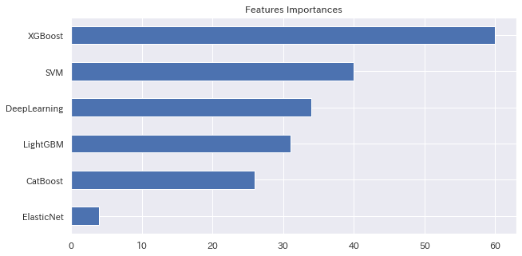

```python
%matplotlib inline
ShowFeatureImportance(model.model.feature_importance(), stacking_feature)
```

```python
# 学習用データの予測結果（Out-of-fold）
oof = pd.DataFrame(model.oof_pred)

# テスト用データの予測結果
pred = pd.DataFrame(model.y_pred)
CheckDF(pred)
```

|  | 欠損数 | 欠-% | 0数 | 0-% | 最小 | 最大 | 中央 | 平均 | 標準偏差 | 種類 |
| --- | --- | --- | --- | --- | --- | --- | --- | --- | --- | --- |
| 0 | 0 | 0.0 | 0 | 0.0 | 2996.1149 | 40415.844992 | 9565.149691 | 11787.052647 | 7932.192814 | float64 |

```python
## 後処理
if TARGET == 'y':
    # 予測数が学習データの最小数より小さい場合、またはスタジアムのキャパシティより大きい場合、それぞれ置換
    mask_min = pred[0]<df_train['y'].min()
    mask_max = pred[0]>df_test['capa']
    print(f'[Before] Too few: {mask_min.sum()}  Too many: {mask_max.sum()}')

    pred[0] = pred[0].where(~mask_min, df_train['y'].min())
    pred[0] = pred[0].where(~mask_max, df_test['capa'])
    mask_min = pred[0]<df_train['y'].min()
    mask_max = pred[0]>df_test['capa']
    print(f'[After]  Too few: {mask_min.sum()}  Too many: {mask_max.sum()}')

elif TARGET == 'y_percent':
    # 予測数が学習データの最小数より小さい場合、またはスタジアムのキャパシティより大きい場合、それぞれ置換
    mask_min = pred[0]<0
    mask_max = pred[0]>100
    print(f'[Before] Too few: {mask_min.sum()}  Too many: {mask_max.sum()}')

    pred[0] = pred[0].where(~mask_min, 0)
    pred[0] = pred[0].where(~mask_max, 100)
    mask_min = pred[0]<0
    mask_max = pred[0]>100
    print(f'[After]  Too few: {mask_min.sum()}  Too many: {mask_max.sum()}')
```

```
[Before] Too few: 0  Too many: 0
[After]  Too few: 0  Too many: 0
```

```python
# idを絞ってSubmit形式に成形
all_test_y = pd.concat([df_test['id'], pred], axis=1)
submit = pd.merge(sample_submit['id'], all_test_y, on='id')
display(submit.head())
```

|  | id | 0 |
| --- | --- | --- |
| 0 | 15822 | 13905.066406 |
| 1 | 15823 | 17942.332660 |
| 2 | 15824 | 40203.103657 |
| 3 | 15825 | 13281.717320 |
| 4 | 15827 | 35944.457983 |

```python
# 出力
suffix = datetime.datetime.now().strftime("%Y%m%d%H%M") + '.csv'
submit.to_csv(f'{full_path}output/submission/submission_stacking_{suffix}', index=None, header=False)
oof.to_csv(f'{full_path}output/oof/oof_stacking_{suffix}', index=None, header=False)
```

### Postprocess

```python
## 後処理
if TARGET == 'y':
    print('There is no postprocessing...')

elif TARGET == 'y_percent':
    # idを絞ってSubmit形式に成形
    all_test_y = pd.concat([df_test[['id', 'capa']], pred], axis=1)
    all_test_y['y_calcurated'] = all_test_y['capa'] * all_test_y[0] / 100
    submit = pd.merge(sample_submit['id'], all_test_y[['id', 'y_calcurated']], on='id')
    display(submit.head())

    # 出力
    submit.to_csv(f'{full_path}output/submission/submission_stacking_calcurated_{suffix}', index=None, header=False)
    oof.to_csv(f'{full_path}output/oof/oof_stacking_calcurated_{suffix}', index=None, header=False)
```

```
There is no postprocessing...
```

## Ensemble - Weighted Average

重みづけ平均と呼ばれる手法でアンサンブル学習を行います。  
各モデルの予測結果に重みを付けて平均を取ったデータを出力する方法です。

### Calcurate

```python
def calc_score(weights, values):
    ret = pd.DataFrame(np.zeros(len(values[0])))
    for w, v in zip(weights, values):
        ret = ret + w*v
    return ret
```

```python
weightedaverage_feature = ['LightGBM', 'XGBoost', 'CatBoost', 'ElasticNet', 'DeepLearning', 'SVM']

weights = [0.3, 0.3, 0.1, 0.1, 0.1, 0.1]

X = [val_lgb, val_xgb, val_cgb, val_liner, val_nn, val_svr]
oof = calc_score(weights, X)
print(f"RMSE Score: {rmse(df_train['y'], oof):.4f}")

X_test = [test_lgb, test_xgb, test_cgb, test_liner, test_nn, test_svr]
pred = calc_score(weights, X_test)
CheckDF(pred)
```

```
RMSE Score: 2844.4860
```

|  | 欠損数 | 欠-% | 0数 | 0-% | 最小 | 最大 | 中央 | 平均 | 標準偏差 | 種類 |
| --- | --- | --- | --- | --- | --- | --- | --- | --- | --- | --- |
| 0 | 0 | 0.0 | 0 | 0.0 | 2828.833863 | 45757.149341 | 9449.233564 | 11787.502125 | 7903.604196 | float64 |

```python
weightedaverage_feature = ['LightGBM', 'XGBoost', 'CatBoost', 'ElasticNet', 'DeepLearning', 'SVM']

weights = [0.3, 0.3, 0.1, 0.1, 0.1, 0.1]

X = [val_lgb, val_xgb, val_cgb, val_liner, val_nn, val_svr]
oof = calc_score(weights, X)
print(f"RMSE Score: {rmse(df_train['y'], oof):.4f}")

X_test = [test_lgb, test_xgb, test_cgb, test_liner, test_nn, test_svr]
pred = calc_score(weights, X_test)
CheckDF(pred)
```

```
RMSE Score: 2844.4860
```

|  | 欠損数 | 欠-% | 0数 | 0-% | 最小 | 最大 | 中央 | 平均 | 標準偏差 | 種類 |
| --- | --- | --- | --- | --- | --- | --- | --- | --- | --- | --- |
| 0 | 0 | 0.0 | 0 | 0.0 | 2828.833863 | 45757.149341 | 9449.233564 | 11787.502125 | 7903.604196 | float64 |

```python
## 後処理
if TARGET == 'y':
    # 予測数が学習データの最小数より小さい場合、またはスタジアムのキャパシティより大きい場合、それぞれ置換
    mask_min = pred[0]<df_train['y'].min()
    mask_max = pred[0]>df_test['capa']
    print(f'[Before] Too few: {mask_min.sum()}  Too many: {mask_max.sum()}')

    pred[0] = pred[0].where(~mask_min, df_train['y'].min())
    pred[0] = pred[0].where(~mask_max, df_test['capa'])
    mask_min = pred[0]<df_train['y'].min()
    mask_max = pred[0]>df_test['capa']
    print(f'[After]  Too few: {mask_min.sum()}  Too many: {mask_max.sum()}')

elif TARGET == 'y_percent':
    # 予測数が学習データの最小数より小さい場合、またはスタジアムのキャパシティより大きい場合、それぞれ置換
    mask_min = pred[0]<0
    mask_max = pred[0]>100
    print(f'[Before] Too few: {mask_min.sum()}  Too many: {mask_max.sum()}')

    pred[0] = pred[0].where(~mask_min, 0)
    pred[0] = pred[0].where(~mask_max, 100)
    mask_min = pred[0]<0
    mask_max = pred[0]>100
    print(f'[After]  Too few: {mask_min.sum()}  Too many: {mask_max.sum()}')
```

```
[Before] Too few: 0  Too many: 0
[After]  Too few: 0  Too many: 0
```

```python
# idを絞ってSubmit形式に成形
all_test_y = pd.concat([df_test['id'], pred], axis=1)
submit = pd.merge(sample_submit['id'], all_test_y, on='id')
display(submit.head())
```

|  | id | 0 |
| --- | --- | --- |
| 0 | 15822 | 13984.782180 |
| 1 | 15823 | 19244.693367 |
| 2 | 15824 | 36231.222691 |
| 3 | 15825 | 13336.686508 |
| 4 | 15827 | 32503.911533 |

```python
# 出力
suffix = datetime.datetime.now().strftime("%Y%m%d%H%M") + '.csv'
submit.to_csv(f'{full_path}output/submission/submission_weightedaverage_{suffix}', index=None, header=False)
oof.to_csv(f'{full_path}output/oof/oof_weightedaverage_{suffix}', index=None, header=False)
```

### Postprocess

```python
## 後処理
if TARGET == 'y':
    print('There is no postprocessing...')

elif TARGET == 'y_percent':
    # idを絞ってSubmit形式に成形
    all_test_y = pd.concat([df_test[['id', 'capa']], pred], axis=1)
    all_test_y['y_calcurated'] = all_test_y['capa'] * all_test_y[0] / 100
    submit = pd.merge(sample_submit['id'], all_test_y[['id', 'y_calcurated']], on='id')
    display(submit.head())

    # 出力
    submit.to_csv(f'{full_path}output/submission/submissionweightedaverage_calcurated_{suffix}', index=None, header=False)
    oof.to_csv(f'{full_path}output/oof/oofweightedaverage_calcurated_{suffix}', index=None, header=False)
```

```
There is no postprocessing...
```

# Parameter Tuning

Optunaと呼ばれるライブラリを使ってパラメータの自動最適化を行います。

```python
# チューニングを実行する場合には 'tuning' を設定
#act_mode = 'tuning'
act_mode = 'skip'

ver = "11_"+TARGET
```

### ElasticNet

```python
def objective(trial):
    params = {
        'alpha': trial.suggest_loguniform('alpha', 1e-5, 1e0),
        'l1_ratio': trial.suggest_uniform('l1_ratio', 0, 1),
        'verbose': 0,
        }

    model = Lin_Model(**train_params_oh, params=params)

    return model.score
```

```python
study_name = f'ElasticNet{ver}'
storage_name = optuna_path + study_name + '.db'
study = optuna.create_study(study_name=study_name, storage=storage_name, load_if_exists=True, direction='minimize')
```

```
[I 2021-09-21 12:42:20,722] Using an existing study with name 'ElasticNet11_y' instead of creating a new one.
```

```python
if act_mode == 'tuning':
    study.optimize(func=objective, n_trials=1, timeout=None)
else:
    print('Skip Tuning...')
```

```
Skip Tuning...
```

```python
print('best_param:{}'.format(study.best_params))
print('====================')
print('best_value:{}'.format(study.best_value))
print('====================')
print('best_trial:{}'.format(study.best_trial))
print('====================')
for i in study.trials:
    print(i)
```

```
best_param:{'alpha': 0.00022962404332219002, 'l1_ratio': 0.3287270979327752}
====================
best_value:3220.358980986134
====================
best_trial:FrozenTrial(number=0, values=[3220.358980986134], datetime_start=datetime.datetime(2021, 9, 21, 3, 52, 11, 348639), datetime_complete=datetime.datetime(2021, 9, 21, 3, 52, 13, 844631), params={'alpha': 0.00022962404332219002, 'l1_ratio': 0.3287270979327752}, distributions={'alpha': LogUni…
====================
FrozenTrial(number=0, values=[3220.358980986134], datetime_start=datetime.datetime(2021, 9, 21, 3, 52, 11, 348639), datetime_complete=datetime.datetime(2021, 9, 21, 3, 52, 13, 844631), params={'alpha': 0.00022962404332219002, 'l1_ratio': 0.3287270979327752}, distributions={'alpha': LogUniformDistrib…
```

### LightGBM

```python
def objective(trial):
    params = {
        # 'num_leaves': trial.suggest_int('num_leaves', 10, 100),  # -> 過学習防止
        'num_leaves': trial.suggest_int('num_leaves', 2, 32),
        # 'max_depth': trial.suggest_int('max_depth', 1, 25),
        'max_depth': trial.suggest_int('max_depth', 1, 5),  # -> 過学習防止
        'min_data_in_leaf': trial.suggest_int('min_data_in_leaf', 1, 20),  # -> 過学習防止
        'learning_rate': trial.suggest_loguniform('learning_rate', 1e-3, 1e0),

        'boosting_type': 'gbdt',
        'objective': 'regression',
        'metric': 'rmse',
        'random_state': random_seed,
        'n_estimators': 10000,
        'early_stopping_rounds': 100,
        'verbose': 0,
        'n_jobs': -1
        }

    model = Lgb_Model(**train_params, params=params)

    return model.score
```

```python
study_name = f'LightGBM{ver}'
storage_name = optuna_path + study_name + '.db'
study = optuna.create_study(study_name=study_name, storage=storage_name, load_if_exists=True, direction='minimize')
```

```
[I 2021-09-21 12:42:20,837] Using an existing study with name 'LightGBM11_y' instead of creating a new one.
```

```python
if act_mode == 'tuning':
    study.optimize(func=objective, n_trials=1, timeout=None)
else:
    print('Skip Tuning...')
```

```
Skip Tuning...
```

```python
print('best_param:{}'.format(study.best_params))
print('====================')
print('best_value:{}'.format(study.best_value))
print('====================')
print('best_trial:{}'.format(study.best_trial))
print('====================')
for i in study.trials:
    print(i)
```

```
best_param:{'learning_rate': 0.003807166990688563, 'max_depth': 1, 'min_data_in_leaf': 14, 'num_leaves': 32}
====================
best_value:3151.8528857165184
====================
best_trial:FrozenTrial(number=0, values=[3151.8528857165184], datetime_start=datetime.datetime(2021, 9, 21, 3, 52, 14, 89288), datetime_complete=datetime.datetime(2021, 9, 21, 3, 52, 27, 34325), params={'learning_rate': 0.003807166990688563, 'max_depth': 1, 'min_data_in_leaf': 14, 'num_leaves': 32},…
====================
FrozenTrial(number=0, values=[3151.8528857165184], datetime_start=datetime.datetime(2021, 9, 21, 3, 52, 14, 89288), datetime_complete=datetime.datetime(2021, 9, 21, 3, 52, 27, 34325), params={'learning_rate': 0.003807166990688563, 'max_depth': 1, 'min_data_in_leaf': 14, 'num_leaves': 32}, distributi…
```

```python
print('best_param:{}'.format(study.best_params))
print('====================')
print('best_value:{}'.format(study.best_value))
print('====================')
print('best_trial:{}'.format(study.best_trial))
print('====================')
for i in study.trials:
    print(i)
```

```
best_param:{'learning_rate': 0.003807166990688563, 'max_depth': 1, 'min_data_in_leaf': 14, 'num_leaves': 32}
====================
best_value:3151.8528857165184
====================
best_trial:FrozenTrial(number=0, values=[3151.8528857165184], datetime_start=datetime.datetime(2021, 9, 21, 3, 52, 14, 89288), datetime_complete=datetime.datetime(2021, 9, 21, 3, 52, 27, 34325), params={'learning_rate': 0.003807166990688563, 'max_depth': 1, 'min_data_in_leaf': 14, 'num_leaves': 32},…
====================
FrozenTrial(number=0, values=[3151.8528857165184], datetime_start=datetime.datetime(2021, 9, 21, 3, 52, 14, 89288), datetime_complete=datetime.datetime(2021, 9, 21, 3, 52, 27, 34325), params={'learning_rate': 0.003807166990688563, 'max_depth': 1, 'min_data_in_leaf': 14, 'num_leaves': 32}, distributi…
```

### XGBoost

```python
def objective(trial):
    params = {
        # 'depth': trial.suggest_int('depth', 1, 10),
        'depth': trial.suggest_int('depth', 1, 5),  # -> 過学習防止
        'learning_rate': trial.suggest_loguniform('learning_rate', 1e-3, 1e0),
        # 'min_child_weight': trial.suggest_int('min_child_weight', 0, 100),  # -> 過学習防止
        # 'gamma': trial.suggest_uniform('gamma', 0, 5),  # -> 過学習防止

        'objective': 'reg:squarederror',
        'eval_metric': 'rmse',
        'random_state': random_seed,
        'n_estimators': 10000,
        'early_stopping_rounds': 100,
        'verbose': 0,
        'n_jobs': -1
        }

    model = Xgb_Model(**train_params, params=params)

    return model.score
```

```python
study_name = f'XGBoost{ver}'
storage_name = optuna_path + study_name + '.db'
study = optuna.create_study(study_name=study_name, storage=storage_name, load_if_exists=True, direction='minimize')
```

```
[I 2021-09-21 12:42:20,998] Using an existing study with name 'XGBoost11_y' instead of creating a new one.
```

```python
if act_mode == 'tuning':
    study.optimize(func=objective, n_trials=1, timeout=None)
else:
    print('Skip Tuning...')
```

```
Skip Tuning...
```

```python
print('best_param:{}'.format(study.best_params))
print('====================')
print('best_value:{}'.format(study.best_value))
print('====================')
print('best_trial:{}'.format(study.best_trial))
print('====================')
for i in study.trials:
    print(i)
```

```
best_param:{'depth': 5, 'learning_rate': 0.0060918818448694925}
====================
best_value:3014.818067406959
====================
best_trial:FrozenTrial(number=0, values=[3014.818067406959], datetime_start=datetime.datetime(2021, 9, 21, 3, 52, 27, 318850), datetime_complete=datetime.datetime(2021, 9, 21, 3, 53, 50, 284630), params={'depth': 5, 'learning_rate': 0.0060918818448694925}, distributions={'depth': IntUniformDistribut…
====================
FrozenTrial(number=0, values=[3014.818067406959], datetime_start=datetime.datetime(2021, 9, 21, 3, 52, 27, 318850), datetime_complete=datetime.datetime(2021, 9, 21, 3, 53, 50, 284630), params={'depth': 5, 'learning_rate': 0.0060918818448694925}, distributions={'depth': IntUniformDistribution(high=5,…
```

### DeepLearning

```python
def objective(trial):
    params = {
        'learning_rate': trial.suggest_loguniform('learning_rate', 1e-2, 1e0),
        'dropout_rate': trial.suggest_uniform('dropout_rate', 0, 1),
        # 'layer1': trial.suggest_discrete_uniform('layer1', 16, 1024, 16),
        # 'layer2': trial.suggest_discrete_uniform('layer2', 16, 1024, 16),
        # 'layer3': trial.suggest_discrete_uniform('layer3', 16, 1024, 16),
        'layer1': trial.suggest_discrete_uniform('layer1', 8, 128, 8),  # -> 過学習防止
        'layer2': trial.suggest_discrete_uniform('layer2', 8, 128, 8),  # -> 過学習防止
        'layer3': trial.suggest_discrete_uniform('layer3', 8, 128, 8),  # -> 過学習防止
        'epochs': 10000,
        'early_stopping_rounds': 20,
        'verbose': 0,  # 表示モード0/1/2
        }

    model = NnReg_Model(**train_params_oh, params=params)

    return model.score
```

```python
study_name = f'DeepLearning{ver}'
storage_name = optuna_path + study_name + '.db'
study = optuna.create_study(study_name=study_name, storage=storage_name, load_if_exists=True, direction='minimize')
```

```
[I 2021-09-21 12:42:21,125] Using an existing study with name 'DeepLearning11_y' instead of creating a new one.
```

```python
if act_mode == 'tuning':
    study.optimize(func=objective, n_trials=1, timeout=None)
else:
    print('Skip Tuning...')
```

```
Skip Tuning...
```

```python
print('best_param:{}'.format(study.best_params))
print('====================')
print('best_value:{}'.format(study.best_value))
print('====================')
print('best_trial:{}'.format(study.best_trial))
print('====================')
for i in study.trials:
    print(i)
```

```
best_param:{'dropout_rate': 0.8719688628679023, 'layer1': 16.0, 'layer2': 32.0, 'layer3': 128.0, 'learning_rate': 0.4529583168843367}
====================
best_value:8091.413960957748
====================
best_trial:FrozenTrial(number=0, values=[8091.413960957748], datetime_start=datetime.datetime(2021, 9, 21, 3, 53, 50, 551900), datetime_complete=datetime.datetime(2021, 9, 21, 3, 54, 13, 807217), params={'dropout_rate': 0.8719688628679023, 'layer1': 16.0, 'layer2': 32.0, 'layer3': 128.0, 'learning_r…
====================
FrozenTrial(number=0, values=[8091.413960957748], datetime_start=datetime.datetime(2021, 9, 21, 3, 53, 50, 551900), datetime_complete=datetime.datetime(2021, 9, 21, 3, 54, 13, 807217), params={'dropout_rate': 0.8719688628679023, 'layer1': 16.0, 'layer2': 32.0, 'layer3': 128.0, 'learning_rate': 0.452…
```

### SVM

```python
def objective(trial):
    params = {
        'C': trial.suggest_loguniform('C', 1e-5, 1e5),
        'gamma': trial.suggest_loguniform('gamma', 1e-5, 1e5),
        'verbose': 0,
        }

    model = Svr_Model(**train_params_oh, params=params)

    return model.score
```

```python
study_name = f'SVM{ver}'
storage_name = optuna_path + study_name + '.db'
study = optuna.create_study(study_name=study_name, storage=storage_name, load_if_exists=True, direction='minimize')
```

```
[I 2021-09-21 12:42:21,253] Using an existing study with name 'SVM11_y' instead of creating a new one.
```

```python
if act_mode == 'tuning':
    study.optimize(func=objective, n_trials=1, timeout=None)
else:
    print('Skip Tuning...')
```

```
Skip Tuning...
```

```python
print('best_param:{}'.format(study.best_params))
print('====================')
print('best_value:{}'.format(study.best_value))
print('====================')
print('best_trial:{}'.format(study.best_trial))
print('====================')
for i in study.trials:
    print(i)
```

```
best_param:{'C': 3.5270908859315617, 'gamma': 0.026398213836042423}
====================
best_value:8172.666248842156
====================
best_trial:FrozenTrial(number=0, values=[8172.666248842156], datetime_start=datetime.datetime(2021, 9, 21, 3, 54, 14, 17556), datetime_complete=datetime.datetime(2021, 9, 21, 3, 54, 22, 884432), params={'C': 3.5270908859315617, 'gamma': 0.026398213836042423}, distributions={'C': LogUniformDistributi…
====================
FrozenTrial(number=0, values=[8172.666248842156], datetime_start=datetime.datetime(2021, 9, 21, 3, 54, 14, 17556), datetime_complete=datetime.datetime(2021, 9, 21, 3, 54, 22, 884432), params={'C': 3.5270908859315617, 'gamma': 0.026398213836042423}, distributions={'C': LogUniformDistribution(high=100…
```

### CatBoost

```python
def objective(trial):
    params = {
        # 'depth': trial.suggest_int('depth', 1, 16),
        'depth': trial.suggest_int('depth', 1, 5),  # -> 過学習防止
        'learning_rate': trial.suggest_loguniform('learning_rate', 1e-2, 1e0),
        'random_strength' :trial.suggest_int('random_strength', 0, 10),
        'bagging_temperature' :trial.suggest_loguniform('bagging_temperature', 0.01, 10),
        'has_time': trial.suggest_categorical('has_time', [True, False]),
        'loss_function': 'RMSE',
        'has_time': True,
        'use_best_model': True,
        'random_seed': random_seed,
        'num_boost_round': 10000,
        'early_stopping_rounds': 100,
        'verbose': 0,
        'is_probability': False,
        }
    if env == 'Colab':
        params['task_type'] = 'GPU'

    model = Cgb_Model(**train_params, params=params)

    return model.score
```

```python
study_name = f'CatBoost{ver}'
storage_name = optuna_path + study_name + '.db'
study = optuna.create_study(study_name=study_name, storage=storage_name, load_if_exists=True, direction='minimize')
```

```
[I 2021-09-21 12:42:21,378] Using an existing study with name 'CatBoost11_y' instead of creating a new one.
```

```python
if act_mode == 'tuning':
    study.optimize(func=objective, n_trials=1, timeout=None)
else:
    print('Skip Tuning...')
```

```
Skip Tuning...
```

```python
print('best_param:{}'.format(study.best_params))
print('====================')
print('best_value:{}'.format(study.best_value))
print('====================')
print('best_trial:{}'.format(study.best_trial))
print('====================')
for i in study.trials:
    print(i)
```

```
best_param:{'bagging_temperature': 3.4618538563191423, 'depth': 1, 'has_time': False, 'learning_rate': 0.9981882232298238, 'random_strength': 2}
====================
best_value:3585.4135762835917
====================
best_trial:FrozenTrial(number=0, values=[3585.4135762835917], datetime_start=datetime.datetime(2021, 9, 21, 3, 54, 23, 121315), datetime_complete=datetime.datetime(2021, 9, 21, 3, 54, 45, 317265), params={'bagging_temperature': 3.4618538563191423, 'depth': 1, 'has_time': False, 'learning_rate': 0.99…
====================
FrozenTrial(number=0, values=[3585.4135762835917], datetime_start=datetime.datetime(2021, 9, 21, 3, 54, 23, 121315), datetime_complete=datetime.datetime(2021, 9, 21, 3, 54, 45, 317265), params={'bagging_temperature': 3.4618538563191423, 'depth': 1, 'has_time': False, 'learning_rate': 0.9981882232298…
```

# Feature Selection

寄与度が低い特徴量を選定します。  
※「特徴量設定」で選定した特徴量を設定しています。

## Boruta

```python
%%time
model =  RandomForestRegressor(n_estimators=200, n_jobs=-1, max_depth=5, random_state=random_seed)

boruta_selector = BorutaPy(model, n_estimators='auto', random_state=random_seed, max_iter=200, verbose=0)
boruta_selector.fit(np.array(df_train[feature]), np.array(df_train[TARGET]))

boruta_ranking = boruta_selector.ranking_
selected_features = np.array(feature)[boruta_ranking <= 2]
```

```
Wall time: 1min 52s
```

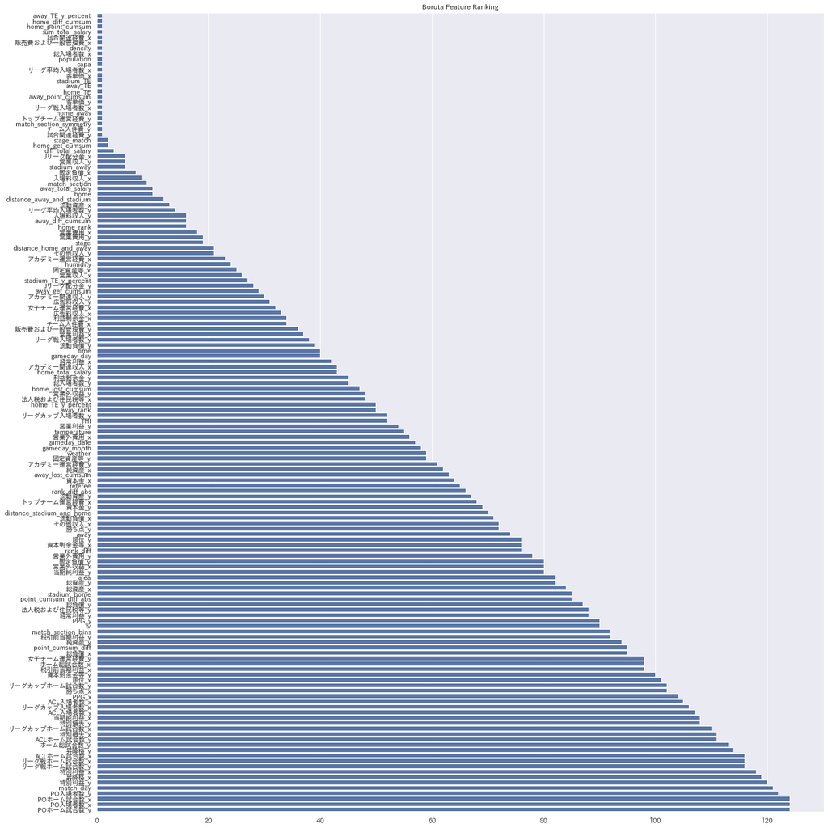

```python
%matplotlib inline
sns.set(font="IPAexGothic") #日本語フォント設定
boruta_ranking = pd.DataFrame(data=boruta_ranking, index=df_train[feature].columns.values, columns=['values'])
boruta_ranking['Variable'] = boruta_ranking.index
boruta_ranking.sort_values(['values'], ascending=True, inplace=True)
fig,ax = plt.subplots(figsize=(20,20))
ax = sns.barplot(x='values',y='Variable',data=boruta_ranking, color='b')
plt.title('Boruta Feature Ranking')
plt.xlabel('')
plt.ylabel('')
plt.tight_layout()
```

```python
boruta_ranking
```

|  | values | Variable |
| --- | --- | --- |
| away_TE_y_percent | 1 | away_TE_y_percent |
| home_diff_cumsum | 1 | home_diff_cumsum |
| home_point_cumsum | 1 | home_point_cumsum |
| sum_total_salary | 1 | sum_total_salary |
| 試合関連経費_x | 1 | 試合関連経費_x |
| 販売費および一般管理費_x | 1 | 販売費および一般管理費_x |
| dencity | 1 | dencity |
| 総入場者数_x | 1 | 総入場者数_x |
| population | 1 | population |
| capa | 1 | capa |
| リーグ平均入場者数_x | 1 | リーグ平均入場者数_x |
| 客単価_x | 1 | 客単価_x |
| stadium_TE | 1 | stadium_TE |
| away_TE | 1 | away_TE |
| home_TE | 1 | home_TE |
| away_point_cumsum | 1 | away_point_cumsum |
| 客単価_y | 1 | 客単価_y |
| リーグ戦入場者数_x | 1 | リーグ戦入場者数_x |
| home_away | 1 | home_away |
| トップチーム運営経費_y | 1 | トップチーム運営経費_y |
| match_section_symmetry | 1 | match_section_symmetry |
| チーム人件費_y | 1 | チーム人件費_y |
| 試合関連経費_y | 1 | 試合関連経費_y |
| stage_match | 2 | stage_match |
| home_get_cumsum | 2 | home_get_cumsum |
| diff_total_salary | 3 | diff_total_salary |
| Jリーグ配分金_x | 5 | Jリーグ配分金_x |
| 営業収入_y | 5 | 営業収入_y |
| stadium_away | 5 | stadium_away |
| 固定負債_x | 7 | 固定負債_x |

[output cut: 118 more lines]

```python
list(boruta_ranking.index)
```

```
['away_TE_y_percent',
 'home_diff_cumsum',
 'home_point_cumsum',
 'sum_total_salary',
 '試合関連経費_x',
 '販売費および一般管理費_x',
 'dencity',
 '総入場者数_x',
 'population',
 'capa',
 'リーグ平均入場者数_x',
 '客単価_x',
 'stadium_TE',
 'away_TE',
 'home_TE',
 'away_point_cumsum',
 '客単価_y',
 'リーグ戦入場者数_x',
 'home_away',
 'トップチーム運営経費_y',
 'match_section_symmetry',
 'チーム人件費_y',
 '試合関連経費_y',
 'stage_match',
 'home_get_cumsum',
 'diff_total_salary',
 'Jリーグ配分金_x',
 '営業収入_y',
 'stadium_away',
 '固定負債_x',
 '入場料収入_x',
 'match_section',
 'away_total_salary',
 'home',
 'distance_away_and_stadium',
 '流動資産_x',
 'リーグ平均入場者数_y',
 '入場料収入_y',
 'away_diff_cumsum',
 'home_rank',
```

[output cut: 93 more lines]

```
 '特別損失_x',
 'ACLホーム試合数_y',
 'ホーム総試合数_y',
 '昇降格_y',
 'ACLホーム試合数_x',
 'リーグ戦ホーム試合数_x',
 'リーグ戦ホーム試合数_y',
 '特別利益_x',
 '昇降格_x',
 '特別利益_y',
 'match_day',
 'PO入場者数_y',
 'POホーム試合数_x',
 'PO入場者数_x',
 'POホーム試合数_y']
```

## Lasso

```python
scaler = StandardScaler()
df_train_std = scaler.fit_transform(df_train[feature])

model = Lasso(alpha=1e0)
model.fit(df_train_std, df_train[TARGET])
```

```
Lasso(alpha=1.0, copy_X=True, fit_intercept=True, max_iter=1000,
      normalize=False, positive=False, precompute=False, random_state=None,
      selection='cyclic', tol=0.0001, warm_start=False)
```

```
Number of features used: 122/148
```

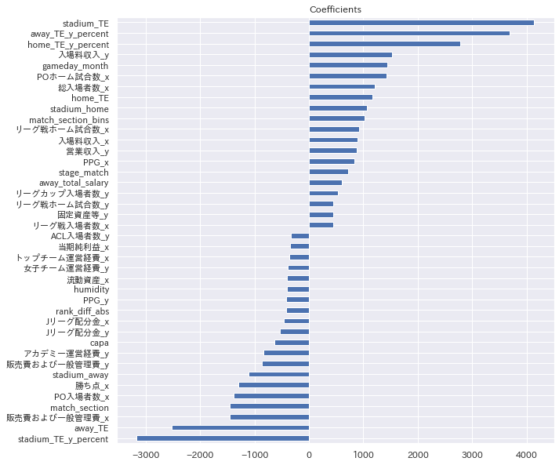

```python
n = 40

coef = pd.Series(model.coef_, index=feature)
matplotlib.rcParams['figure.figsize'] = (10, 10)
imp_coef = pd.concat([coef.sort_values().head(int(n/2)), coef.sort_values().tail(int(n/2))])
imp_coef.plot(kind="barh")
plt.title("Coefficients")
print("Number of features used: {}/{}".format(np.sum(coef != 0), len(coef)))
```

```python
list(coef[coef!=0].index)
```

```
['stage',
 'time',
 'home',
 'away',
 'tv',
 'match_section',
 'match_day',
 'match_section_bins',
 'gameday_month',
 'gameday_date',
 'gameday_day',
 'stadium_home',
 'stadium_away',
 'stage_match',
 'home_away',
 'home_TE',
 'away_TE',
 'stadium_TE',
 'home_TE_y_percent',
 'away_TE_y_percent',
 'stadium_TE_y_percent',
 'capa',
 'population',
 'area',
 'dencity',
 'weather',
 'temperature',
 'humidity',
 'referee',
 'THI',
 'home_total_salary',
 'away_total_salary',
 'sum_total_salary',
 'home_rank',
 'home_point_cumsum',
 'home_lost_cumsum',
 'home_diff_cumsum',
 'away_rank',
 'away_lost_cumsum',
 'away_diff_cumsum',
```

[output cut: 67 more lines]

```
 'リーグ平均入場者数_y',
 '客単価_y',
 'リーグ戦入場者数_y',
 'リーグ戦ホーム試合数_y',
 'リーグカップ入場者数_y',
 'リーグカップホーム試合数_y',
 'POホーム試合数_y',
 'ACL入場者数_y',
 'ACLホーム試合数_y',
 'rank_diff_abs',
 'point_cumsum_diff',
 'point_cumsum_diff_abs',
 'distance_stadium_and_home',
 'distance_home_and_away',
 'distance_away_and_stadium']
```

```python
print("End Time: ", datetime.datetime.now())
```

```
End Time:  2021-09-21 12:44:16.575924
```